# DDK Modelling spatial variability

# 6 Exploratory testing

## 6.1 Compare different predictors

```r
summary(mPace <- bam(spat_var_bivariate ~ s(pace) + groupO + s(subj,bs='re'), data = df, family =Gamma(link=log)), select = T, discrete = T, nthreads = 10)
```

```
##
## Family: Gamma
## Link function: log
##
## Formula:
## spat_var_bivariate ~ s(pace) + groupO + s(subj, bs = "re")
##
## Parametric coefficients:
##               Estimate Std. Error t value Pr(>|t|)
## (Intercept)   -0.37028    0.05473  -6.766 5.19e-11 ***
## groupOtypical  0.32665    0.07455   4.382 1.53e-05 ***
## ---
## Signif. codes:  0 '***' 0.001 '**' 0.01 '*' 0.05 '.' 0.1 ' ' 1
##
## Approximate significance of smooth terms:
##           edf Ref.df     F  p-value
## s(pace)  1.00      1 9.820  0.00186 **
## s(subj) 23.45     40 1.511 3.46e-06 ***
## ---
## Signif. codes:  0 '***' 0.001 '**' 0.01 '*' 0.05 '.' 0.1 ' ' 1
##
## R-sq.(adj) =  0.215   Deviance explained = 29.8%
## fREML = 266.58  Scale est. = 0.19797   n = 397
```

```r
summary(mSpeed <- bam(spat_var_bivariate ~ s(mean.speed2target) + groupO + s(subj,bs='re'), data = df, family =Gamma(link=log)), select = T, discrete = T, nthreads = 10)
```

```
##
## Family: Gamma
## Link function: log
##
## Formula:
## spat_var_bivariate ~ s(mean.speed2target) + groupO + s(subj,
##     bs = "re")
##
## Parametric coefficients:
##               Estimate Std. Error t value Pr(>|t|)
## (Intercept)   -0.34492    0.06034  -5.716 2.27e-08 ***
## groupOtypical  0.26926    0.08275   3.254  0.00125 **
## ---
## Signif. codes:  0 '***' 0.001 '**' 0.01 '*' 0.05 '.' 0.1 ' ' 1
##
## Approximate significance of smooth terms:
##                         edf Ref.df     F  p-value
## s(mean.speed2target)  4.449  5.447 4.302 0.000615 ***
## s(subj)              26.509 40.000 2.058  < 2e-16 ***
## ---
## Signif. codes:  0 '***' 0.001 '**' 0.01 '*' 0.05 '.' 0.1 ' ' 1
##
## R-sq.(adj) =  0.251   Deviance explained =   35%
## fREML = 260.54  Scale est. = 0.18371   n = 397
```

```r
summary(mStiffness <- bam(spat_var_bivariate ~ s(mean.stiffness2target) + groupO + s(subj,bs='re'), data = df, family =Gamma(link=log)), select = T, discrete = T, nthreads = 10)
```

```
##
## Family: Gamma
## Link function: log
##
## Formula:
## spat_var_bivariate ~ s(mean.stiffness2target) + groupO + s(subj,
##     bs = "re")
##
## Parametric coefficients:
##               Estimate Std. Error t value Pr(>|t|)
## (Intercept)   -0.36824    0.05560  -6.622 1.25e-10 ***
## groupOtypical  0.32426    0.07575   4.281 2.37e-05 ***
## ---
## Signif. codes:  0 '***' 0.001 '**' 0.01 '*' 0.05 '.' 0.1 ' ' 1
##
## Approximate significance of smooth terms:
##                            edf Ref.df     F  p-value
## s(mean.stiffness2target)  1.00      1 8.996  0.00289 **
## s(subj)                  23.84     40 1.561 2.39e-06 ***
## ---
## Signif. codes:  0 '***' 0.001 '**' 0.01 '*' 0.05 '.' 0.1 ' ' 1
##
## R-sq.(adj) =  0.215   Deviance explained =   30%
## fREML =  268.6  Scale est. = 0.19949   n = 397
```

```r
summary(mDist2target <- bam(spat_var_bivariate ~ s(mean.dist2target) + groupO + s(subj,bs='re'), data = df, family =Gamma(link=log)), select = T, discrete = T, nthreads = 10)
```

```
##
## Family: Gamma
## Link function: log
##
## Formula:
## spat_var_bivariate ~ s(mean.dist2target) + groupO + s(subj, bs = "re")
##
## Parametric coefficients:
##               Estimate Std. Error t value Pr(>|t|)
## (Intercept)   -0.33509    0.05974  -5.609 4.01e-08 ***
## groupOtypical  0.25661    0.08136   3.154  0.00174 **
## ---
## Signif. codes:  0 '***' 0.001 '**' 0.01 '*' 0.05 '.' 0.1 ' ' 1
##
## Approximate significance of smooth terms:
##                        edf Ref.df     F p-value
## s(mean.dist2target)  3.729  4.578 2.136  0.0692 .
## s(subj)             25.901 40.000 1.920  <2e-16 ***
## ---
## Signif. codes:  0 '***' 0.001 '**' 0.01 '*' 0.05 '.' 0.1 ' ' 1
##
## R-sq.(adj) =  0.225   Deviance explained = 32.3%
## fREML =  267.8  Scale est. = 0.19252   n = 397
```

```r
summary(mTime2target <- bam(spat_var_bivariate ~ s(mean.time2target) + groupO + s(subj,bs='re'), data = df, family =Gamma(link=log)), select = T, discrete = T, nthreads = 10)
```

```
##
## Family: Gamma
## Link function: log
##
## Formula:
## spat_var_bivariate ~ s(mean.time2target) + groupO + s(subj, bs = "re")
##
## Parametric coefficients:
##               Estimate Std. Error t value Pr(>|t|)
## (Intercept)   -0.37858    0.05647  -6.704 7.61e-11 ***
## groupOtypical  0.34057    0.07737   4.402 1.41e-05 ***
## ---
## Signif. codes:  0 '***' 0.001 '**' 0.01 '*' 0.05 '.' 0.1 ' ' 1
##
## Approximate significance of smooth terms:
##                        edf Ref.df     F  p-value
## s(mean.time2target)  1.192  1.331 7.902   0.0045 **
## s(subj)             24.214 40.000 1.613 1.47e-06 ***
## ---
## Signif. codes:  0 '***' 0.001 '**' 0.01 '*' 0.05 '.' 0.1 ' ' 1
##
## R-sq.(adj) =   0.22   Deviance explained = 30.4%
## fREML = 266.66  Scale est. = 0.19691   n = 397
```

```r
summary(mGestdur <- bam(spat_var_bivariate ~ s(mean.gest.dur) + groupO + s(subj,bs='re'), data = df, family =Gamma(link=log)), select = T, discrete = T, nthreads = 10)
```

```
##
## Family: Gamma
## Link function: log
##
## Formula:
## spat_var_bivariate ~ s(mean.gest.dur) + groupO + s(subj, bs = "re")
##
## Parametric coefficients:
##               Estimate Std. Error t value Pr(>|t|)
## (Intercept)   -0.37157    0.05533  -6.716 7.06e-11 ***
## groupOtypical  0.32855    0.07568   4.342 1.83e-05 ***
## ---
## Signif. codes:  0 '***' 0.001 '**' 0.01 '*' 0.05 '.' 0.1 ' ' 1
##
## Approximate significance of smooth terms:
##                     edf Ref.df     F p-value
## s(mean.gest.dur)  1.422  1.679 5.339  0.0199 *
## s(subj)          23.392 40.000 1.506 3.2e-06 ***
## ---
## Signif. codes:  0 '***' 0.001 '**' 0.01 '*' 0.05 '.' 0.1 ' ' 1
##
## R-sq.(adj) =  0.211   Deviance explained = 29.5%
## fREML = 268.23  Scale est. = 0.19934   n = 397
```

```r
summary(mPeakvel <- bam(spat_var_bivariate ~ s(mean.peakvel2target) + groupO + s(subj,bs='re'), data = df, family =Gamma(link=log)), select = T, discrete = T, nthreads = 10)
```

```
##
## Family: Gamma
## Link function: log
##
## Formula:
## spat_var_bivariate ~ s(mean.peakvel2target) + groupO + s(subj,
##     bs = "re")
##
## Parametric coefficients:
##               Estimate Std. Error t value Pr(>|t|)
## (Intercept)   -0.34714    0.06109  -5.683 2.72e-08 ***
## groupOtypical  0.27246    0.08369   3.255  0.00124 **
## ---
## Signif. codes:  0 '***' 0.001 '**' 0.01 '*' 0.05 '.' 0.1 ' ' 1
##
## Approximate significance of smooth terms:
##                           edf Ref.df     F  p-value
## s(mean.peakvel2target)  4.329  5.299 4.393 0.000569 ***
## s(subj)                26.912 40.000 2.155  < 2e-16 ***
## ---
## Signif. codes:  0 '***' 0.001 '**' 0.01 '*' 0.05 '.' 0.1 ' ' 1
##
## R-sq.(adj) =  0.253   Deviance explained = 35.3%
## fREML = 259.84  Scale est. = 0.1826    n = 397
```

```r
summary(mAccphase <- bam(spat_var_bivariate ~ s(mean.dur.accphase) + groupO + s(subj,bs='re'), data = df, family =Gamma(link=log)), select = T, discrete = T, nthreads = 10)
```

```
##
## Family: Gamma
## Link function: log
##
## Formula:
## spat_var_bivariate ~ s(mean.dur.accphase) + groupO + s(subj,
##     bs = "re")
##
## Parametric coefficients:
##               Estimate Std. Error t value Pr(>|t|)
## (Intercept)   -0.38907    0.05716  -6.806 4.09e-11 ***
## groupOtypical  0.35893    0.07874   4.558 7.03e-06 ***
## ---
## Signif. codes:  0 '***' 0.001 '**' 0.01 '*' 0.05 '.' 0.1 ' ' 1
##
## Approximate significance of smooth terms:
##                        edf Ref.df     F  p-value
## s(mean.dur.accphase)  2.85  3.568 5.077  0.00135 **
## s(subj)              24.49 40.000 1.619 1.66e-06 ***
## ---
## Signif. codes:  0 '***' 0.001 '**' 0.01 '*' 0.05 '.' 0.1 ' ' 1
##
## R-sq.(adj) =  0.231   Deviance explained = 32.7%
## fREML =  265.6  Scale est. = 0.19384   n = 397
```

```r
summary(mDecphase <- bam(spat_var_bivariate ~ s(mean.dur.decphase) + groupO + s(subj,bs='re'), data = df, family =Gamma(link=log)), select = T, discrete = T, nthreads = 10)
```

```
##
## Family: Gamma
## Link function: log
##
## Formula:
## spat_var_bivariate ~ s(mean.dur.decphase) + groupO + s(subj,
##     bs = "re")
##
## Parametric coefficients:
##               Estimate Std. Error t value Pr(>|t|)
## (Intercept)   -0.36398    0.05582  -6.521 2.30e-10 ***
## groupOtypical  0.31405    0.07596   4.134 4.41e-05 ***
## ---
## Signif. codes:  0 '***' 0.001 '**' 0.01 '*' 0.05 '.' 0.1 ' ' 1
##
## Approximate significance of smooth terms:
##                        edf Ref.df     F  p-value
## s(mean.dur.decphase)  1.00      1 4.553   0.0335 *
## s(subj)              23.86     40 1.582 1.77e-06 ***
## ---
## Signif. codes:  0 '***' 0.001 '**' 0.01 '*' 0.05 '.' 0.1 ' ' 1
##
## R-sq.(adj) =  0.207   Deviance explained = 29.1%
## fREML = 269.87  Scale est. = 0.20078   n = 397
```

```r
AIC(mPace)
```

```
## [1] 270.665
```

```r
AIC(mSpeed)
```

```
## [1] 252.5197
```

```r
AIC(mStiffness)
```

```
## [1] 271.1223
```

```r
AIC(mDist2target)
```

```
## [1] 267.9658
```

```r
AIC(mTime2target)
```

```
## [1] 271.7686
```

```r
AIC(mGestdur)
```

```
## [1] 274.9702
```

```r
AIC(mPeakvel)
```

```
## [1] 251.4606
```

```r
AIC(mAccphase)
```

```
## [1] 262.6652
```

```r
AIC(mDecphase)
```

```
## [1] 275.8521
```

Peakvel has the lowest AIC.

Check if the model has improved

```r
summary(mPeakvelML <- bam(spat_var_bivariate ~ s(mean.peakvel2target) + groupO + s(subj,bs='re'), data = df, family = Gamma(link=log), method = "ML"))
```

```
##
## Family: Gamma
## Link function: log
##
## Formula:
## spat_var_bivariate ~ s(mean.peakvel2target) + groupO + s(subj,
##     bs = "re")
##
## Parametric coefficients:
##               Estimate Std. Error t value Pr(>|t|)
## (Intercept)   -0.34870    0.05934  -5.876 9.49e-09 ***
## groupOtypical  0.27531    0.08129   3.387 0.000785 ***
## ---
## Signif. codes:  0 '***' 0.001 '**' 0.01 '*' 0.05 '.' 0.1 ' ' 1
##
## Approximate significance of smooth terms:
##                           edf Ref.df     F  p-value
## s(mean.peakvel2target)  4.068  4.988 4.394 0.000684 ***
## s(subj)                26.131 40.000 2.073  < 2e-16 ***
## ---
## Signif. codes:  0 '***' 0.001 '**' 0.01 '*' 0.05 '.' 0.1 ' ' 1
##
## R-sq.(adj) =   0.25   Deviance explained = 34.8%
## -ML = 255.86  Scale est. = 0.18399   n = 397
```

```r
compareML(mFinalHypothesis_gamma2ML, mPeakvelML)
```

```
## mFinalHypothesis_gamma2ML: spat_var_bivariate ~ groupO + s(subj, bs = "re")
##
## mPeakvelML: spat_var_bivariate ~ s(mean.peakvel2target) + groupO + s(subj,
##     bs = "re")
##
## Chi-square test of ML scores
## -----
##                       Model    Score Edf Difference    Df   p.value Sig.
## 1 mFinalHypothesis_gamma2ML 269.0134   3
## 2                mPeakvelML 255.8597   5     13.154 2.000 1.938e-06  ***
##
## AIC difference: 26.88, model mPeakvelML has lower AIC.
```

Yes.

Plot smooth:

```
## Summary:
##  * groupO : factor; set to the value(s): typical.
##  * mean.peakvel2target : numeric predictor; with 30 values ranging from 1.412500 to 33.247800.
##  * subj : factor; set to the value(s): CTRL01. (Might be canceled as random effect, check below.)
##  * NOTE : The following random effects columns are canceled: s(subj)
##
```

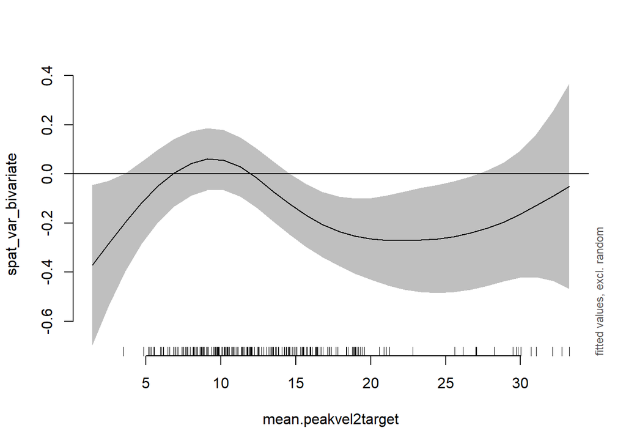

```r
plot_smooth(mPeakvel, view = "mean.peakvel2target")
```

Add random smooth over peakvel:

```r
summary(m1 <- bam(spat_var_bivariate ~ s(mean.peakvel2target) + groupO + s(subj,bs='re') + s(mean.peakvel2target, subj, bs = "fs", m=1, k = 11), data = df, family =Gamma(link=log), discrete = T, nthreads = 10))
```

```
##
## Family: Gamma
## Link function: log
##
## Formula:
## spat_var_bivariate ~ s(mean.peakvel2target) + groupO + s(subj,
##     bs = "re") + s(mean.peakvel2target, subj, bs = "fs", m = 1,
##     k = 11)
##
## Parametric coefficients:
##               Estimate Std. Error t value Pr(>|t|)
## (Intercept)   -0.34967    0.06189  -5.650 3.34e-08 ***
## groupOtypical  0.26755    0.08354   3.202  0.00149 **
## ---
## Signif. codes:  0 '***' 0.001 '**' 0.01 '*' 0.05 '.' 0.1 ' ' 1
##
## Approximate significance of smooth terms:
##                               edf  Ref.df     F p-value
## s(mean.peakvel2target)       4.14   4.979 3.426 0.00485 **
## s(subj)                     12.43  40.000 0.455 < 2e-16 ***
## s(mean.peakvel2target,subj) 29.77 359.000 0.217 0.02613 *
## ---
## Signif. codes:  0 '***' 0.001 '**' 0.01 '*' 0.05 '.' 0.1 ' ' 1
##
## R-sq.(adj) =  0.285   Deviance explained = 41.5%
## fREML = 246.32  Scale est. = 0.17041   n = 397
```

Yes.

Add random slopes per seg over peakvel?

```r
summary(m2 <- bam(spat_var_bivariate ~ segO + s(mean.peakvel2target) + groupO + s(subj,bs='re') +  s(mean.peakvel2target, subj, bs = "fs", m=1, k = 4) + s(mean.peakvel2target, subj, by = segO, bs = "fs", m=1, k = 4), data = df, family =Gamma(link=log), discrete = T, nthreads = 10))
```

```
##
## Family: Gamma
## Link function: log
##
## Formula:
## spat_var_bivariate ~ segO + s(mean.peakvel2target) + groupO +
##     s(subj, bs = "re") + s(mean.peakvel2target, subj, bs = "fs",
##     m = 1, k = 4) + s(mean.peakvel2target, subj, by = segO, bs = "fs",
##     m = 1, k = 4)
##
## Parametric coefficients:
##               Estimate Std. Error t value Pr(>|t|)
## (Intercept)   -0.36629    0.06121  -5.984 5.84e-09 ***
## segOK          0.18136    0.07024   2.582  0.01027 *
## segOT         -0.14059    0.06587  -2.134  0.03358 *
## groupOtypical  0.24914    0.08059   3.091  0.00217 **
## ---
## Signif. codes:  0 '***' 0.001 '**' 0.01 '*' 0.05 '.' 0.1 ' ' 1
##
## Approximate significance of smooth terms:
##                                      edf  Ref.df     F  p-value
## s(mean.peakvel2target)             3.609   4.348 2.021   0.0851 .
## s(subj)                           11.825  40.000 0.420  < 2e-16 ***
## s(mean.peakvel2target,subj)       13.918 159.000 0.189   0.0125 *
## s(mean.peakvel2target,subj):segOK 24.654 110.000 0.588 8.31e-07 ***
## s(mean.peakvel2target,subj):segOT 20.371 129.000 0.386 8.86e-06 ***
## ---
## Signif. codes:  0 '***' 0.001 '**' 0.01 '*' 0.05 '.' 0.1 ' ' 1
##
## R-sq.(adj) =   0.48   Deviance explained = 60.6%
## fREML = 216.75  Scale est. = 0.12426   n = 397
```

Yes.

Plot smooths:

```
## Summary:
##  * segO : factor; set to the value(s): P.
##  * groupO : factor; set to the value(s): typical.
##  * mean.peakvel2target : numeric predictor; with 30 values ranging from 1.412500 to 33.247800.
##  * subj : factor; set to the value(s): CTRL01. (Might be canceled as random effect, check below.)
##  * NOTE : The following random effects columns are canceled: s(subj),s(mean.peakvel2target,subj),s(mean.peakvel2target,subj):segOK,s(mean.peakvel2target,subj):segOT
##
```

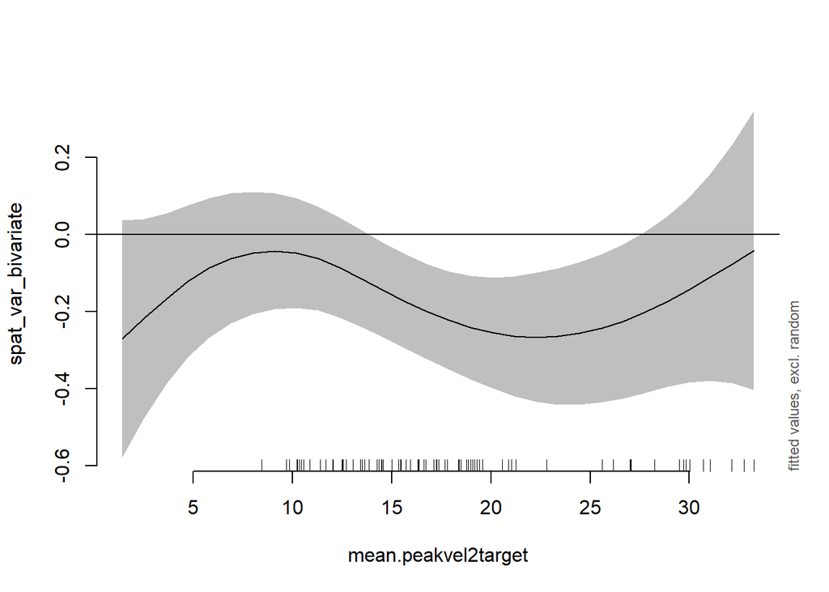

```r
plot_smooth(m2, view = "mean.peakvel2target")
```

Variable pattern.

Separate per group, using ordered factor?

```r
summary(m3 <- bam(spat_var_bivariate ~ segO + s(mean.peakvel2target) + s(mean.peakvel2target, by = groupO) + groupO + s(subj,bs='re') + s(mean.peakvel2target, subj, bs = "fs", m=1, k = 4) + s(mean.peakvel2target, subj, by = segO, bs = "fs", m=1, k = 4), data = df, family =Gamma(link=log), discrete = T, nthreads = 10))
```

```
##
## Family: Gamma
## Link function: log
##
## Formula:
## spat_var_bivariate ~ segO + s(mean.peakvel2target) + s(mean.peakvel2target,
##     by = groupO) + groupO + s(subj, bs = "re") + s(mean.peakvel2target,
##     subj, bs = "fs", m = 1, k = 4) + s(mean.peakvel2target, subj,
##     by = segO, bs = "fs", m = 1, k = 4)
##
## Parametric coefficients:
##               Estimate Std. Error t value Pr(>|t|)
## (Intercept)   -0.36784    0.06184  -5.948 7.18e-09 ***
## segOK          0.18314    0.07051   2.598  0.00983 **
## segOT         -0.13976    0.06632  -2.107  0.03588 *
## groupOtypical  0.24858    0.08076   3.078  0.00226 **
## ---
## Signif. codes:  0 '***' 0.001 '**' 0.01 '*' 0.05 '.' 0.1 ' ' 1
##
## Approximate significance of smooth terms:
##                                         edf  Ref.df     F  p-value
## s(mean.peakvel2target)                3.556   4.294 1.811   0.1209
## s(mean.peakvel2target):groupOtypical  1.000   1.000 0.009   0.9250
## s(subj)                              11.557  40.000 0.407  < 2e-16 ***
## s(mean.peakvel2target,subj)          15.275 159.000 0.201   0.0107 *
## s(mean.peakvel2target,subj):segOK    24.520 111.000 0.565 8.90e-07 ***
## s(mean.peakvel2target,subj):segOT    20.265 129.000 0.381 7.65e-06 ***
## ---
## Signif. codes:  0 '***' 0.001 '**' 0.01 '*' 0.05 '.' 0.1 ' ' 1
##
## R-sq.(adj) =  0.481   Deviance explained =   61%
## fREML =  218.5  Scale est. = 0.12382   n = 397
```

No, and it is non significant as a fixed effect, so we take it out.

Add pace?

```r
summary(m4 <- bam(spat_var_bivariate ~ segO + s(pace) + groupO + s(subj,bs='re'), data = df, family =Gamma(link=log), discrete = T, nthreads = 10))
```

```
##
## Family: Gamma
## Link function: log
##
## Formula:
## spat_var_bivariate ~ segO + s(pace) + groupO + s(subj, bs = "re")
##
## Parametric coefficients:
##               Estimate Std. Error t value Pr(>|t|)
## (Intercept)   -0.40516    0.06168  -6.569 1.73e-10 ***
## segOK          0.22305    0.05570   4.004 7.53e-05 ***
## segOT         -0.09056    0.05225  -1.733   0.0839 .
## groupOtypical  0.31261    0.07478   4.180 3.65e-05 ***
## ---
## Signif. codes:  0 '***' 0.001 '**' 0.01 '*' 0.05 '.' 0.1 ' ' 1
##
## Approximate significance of smooth terms:
##           edf Ref.df     F p-value
## s(pace)  1.00      1 2.975  0.0854 .
## s(subj) 24.66     40 1.720  <2e-16 ***
## ---
## Signif. codes:  0 '***' 0.001 '**' 0.01 '*' 0.05 '.' 0.1 ' ' 1
##
## R-sq.(adj) =   0.29   Deviance explained = 36.6%
## fREML = 237.98  Scale est. = 0.18209   n = 397
```

No.

Add random smooth per seg over pace?

```r
summary(m4Random <- bam(spat_var_bivariate ~ segO + s(pace) + groupO + s(subj,bs='re') + s(pace, subj, bs = "fs", m=1, k = 4) + s(pace, subj, by = segO, bs = "fs", m=1, k = 4), data = df, family =Gamma(link=log), discrete = T, nthreads = 10))
```

```
##
## Family: Gamma
## Link function: log
##
## Formula:
## spat_var_bivariate ~ segO + s(pace) + groupO + s(subj, bs = "re") +
##     s(pace, subj, bs = "fs", m = 1, k = 4) + s(pace, subj, by = segO,
##     bs = "fs", m = 1, k = 4)
##
## Parametric coefficients:
##               Estimate Std. Error t value Pr(>|t|)
## (Intercept)   -0.39642    0.06089  -6.510 2.96e-10 ***
## segOK          0.21994    0.06684   3.291 0.001113 **
## segOT         -0.11495    0.06075  -1.892 0.059391 .
## groupOtypical  0.26547    0.07829   3.391 0.000785 ***
## ---
## Signif. codes:  0 '***' 0.001 '**' 0.01 '*' 0.05 '.' 0.1 ' ' 1
##
## Approximate significance of smooth terms:
##                      edf Ref.df     F  p-value
## s(pace)             1.00      1 0.820  0.36597
## s(subj)             8.49     40 0.270  < 2e-16 ***
## s(pace,subj)       23.34    159 0.307  0.00207 **
## s(pace,subj):segOK 20.54    109 0.460 3.41e-06 ***
## s(pace,subj):segOT 24.83    128 0.431 5.09e-06 ***
## ---
## Signif. codes:  0 '***' 0.001 '**' 0.01 '*' 0.05 '.' 0.1 ' ' 1
##
## R-sq.(adj) =  0.464   Deviance explained = 60.9%
## fREML = 218.75  Scale est. = 0.12308   n = 397
```

Yes.

Add pace per group?

```r
summary(m5 <- bam(spat_var_bivariate ~ segO + s(pace) + s(pace, by = groupO) + groupO + s(subj,bs='re') + s(pace, subj, bs = "fs", m=1, k = 4) + s(pace, subj, by = segO, bs = "fs", m=1, k = 4), data = df, family =Gamma(link=log), discrete = T, nthreads = 10))
```

```
##
## Family: Gamma
## Link function: log
##
## Formula:
## spat_var_bivariate ~ segO + s(pace) + s(pace, by = groupO) +
##     groupO + s(subj, bs = "re") + s(pace, subj, bs = "fs", m = 1,
##     k = 4) + s(pace, subj, by = segO, bs = "fs", m = 1, k = 4)
##
## Parametric coefficients:
##               Estimate Std. Error t value Pr(>|t|)
## (Intercept)   -0.39416    0.06081  -6.482 3.51e-10 ***
## segOK          0.22120    0.06686   3.309  0.00105 **
## segOT         -0.11516    0.06073  -1.896  0.05885 .
## groupOtypical  0.26810    0.07803   3.436  0.00067 ***
## ---
## Signif. codes:  0 '***' 0.001 '**' 0.01 '*' 0.05 '.' 0.1 ' ' 1
##
## Approximate significance of smooth terms:
##                          edf Ref.df     F  p-value
## s(pace)                1.000      1 0.039   0.8432
## s(pace):groupOtypical  1.000      1 0.432   0.5115
## s(subj)                8.059     40 0.253  < 2e-16 ***
## s(pace,subj)          23.573    159 0.310   0.0016 **
## s(pace,subj):segOK    20.485    110 0.453 3.24e-06 ***
## s(pace,subj):segOT    24.858    128 0.431 4.83e-06 ***
## ---
## Signif. codes:  0 '***' 0.001 '**' 0.01 '*' 0.05 '.' 0.1 ' ' 1
##
## R-sq.(adj) =  0.464   Deviance explained =   61%
## fREML = 220.17  Scale est. = 0.12308   n = 397
```

No.

Do we need the interaction between pace and peakvel (including random smooths)?

```r
summary(m6 <- bam(spat_var_bivariate ~ segO + s(pace) + s(pace) + ti(pace, mean.peakvel2target) + groupO + s(pace, subj, bs = "fs", m=1, k = 4) + s(pace, subj, by = segO, bs = "fs", m=1, k = 4) + s(mean.peakvel2target, subj, bs = "fs", m=1, k = 4) + s(mean.peakvel2target, subj, by = segO, bs = "fs", m=1, k = 4), data = df, family =Gamma(link=log), discrete = T, nthreads = 10))
```

```
##
## Family: Gamma
## Link function: log
##
## Formula:
## spat_var_bivariate ~ segO + s(pace) + s(pace) + ti(pace, mean.peakvel2target) +
##     groupO + s(pace, subj, bs = "fs", m = 1, k = 4) + s(pace,
##     subj, by = segO, bs = "fs", m = 1, k = 4) + s(mean.peakvel2target,
##     subj, bs = "fs", m = 1, k = 4) + s(mean.peakvel2target, subj,
##     by = segO, bs = "fs", m = 1, k = 4)
##
## Parametric coefficients:
##               Estimate Std. Error t value Pr(>|t|)
## (Intercept)   -0.37218    0.06371  -5.842 1.35e-08 ***
## segOK          0.23756    0.06607   3.596 0.000379 ***
## segOT         -0.11941    0.06183  -1.931 0.054394 .
## groupOtypical  0.23527    0.08052   2.922 0.003747 **
## ---
## Signif. codes:  0 '***' 0.001 '**' 0.01 '*' 0.05 '.' 0.1 ' ' 1
##
## Approximate significance of smooth terms:
##                                         edf Ref.df     F  p-value
## s(pace)                           1.000e+00      1 0.633 0.426909
## ti(pace,mean.peakvel2target)      1.000e+00      1 0.455 0.500707
## s(pace,subj)                      2.420e+01    159 0.240  < 2e-16 ***
## s(pace,subj):segOK                1.231e-04    119 0.000 0.000544 ***
## s(pace,subj):segOT                1.983e+01    128 0.253  < 2e-16 ***
## s(mean.peakvel2target,subj)       1.559e+01    159 0.131 5.47e-07 ***
## s(mean.peakvel2target,subj):segOK 2.605e+01    111 0.594  < 2e-16 ***
## s(mean.peakvel2target,subj):segOT 7.547e+00    132 0.068 2.19e-06 ***
## ---
## Signif. codes:  0 '***' 0.001 '**' 0.01 '*' 0.05 '.' 0.1 ' ' 1
##
## R-sq.(adj) =   0.52   Deviance explained = 66.8%
## fREML = 212.94  Scale est. = 0.11038   n = 397
```

No.

Do we need the interaction between pace and peakvel per group (including random smooths)?

```r
summary(m7 <- bam(spat_var_bivariate ~ segO + s(pace) + s(mean.peakvel2target) + ti(pace, mean.peakvel2target) + ti(pace, mean.peakvel2target, by = groupO) + groupO + s(pace, subj, bs = "fs", m=1, k = 4) + s(pace, subj, by = segO, bs = "fs", m=1, k = 4) + s(mean.peakvel2target, subj, bs = "fs", m=1, k = 4) + s(mean.peakvel2target, subj, by = segO, bs = "fs", m=1, k = 4), data = df, family =Gamma(link=log), discrete = T, nthreads = 10))
```

```
##
## Family: Gamma
## Link function: log
##
## Formula:
## spat_var_bivariate ~ segO + s(pace) + s(mean.peakvel2target) +
##     ti(pace, mean.peakvel2target) + ti(pace, mean.peakvel2target,
##     by = groupO) + groupO + s(pace, subj, bs = "fs", m = 1, k = 4) +
##     s(pace, subj, by = segO, bs = "fs", m = 1, k = 4) + s(mean.peakvel2target,
##     subj, bs = "fs", m = 1, k = 4) + s(mean.peakvel2target, subj,
##     by = segO, bs = "fs", m = 1, k = 4)
##
## Parametric coefficients:
##               Estimate Std. Error t value Pr(>|t|)
## (Intercept)   -0.34088    0.06651  -5.126 5.35e-07 ***
## segOK          0.13160    0.08117   1.621  0.10604
## segOT         -0.18325    0.06974  -2.628  0.00904 **
## groupOtypical  0.27417    0.09031   3.036  0.00261 **
## ---
## Signif. codes:  0 '***' 0.001 '**' 0.01 '*' 0.05 '.' 0.1 ' ' 1
##
## Approximate significance of smooth terms:
##                                                  edf  Ref.df     F  p-value
## s(pace)                                    1.000e+00   1.000 1.985  0.15996
## s(mean.peakvel2target)                     3.490e+00   4.201 2.298  0.05518 .
## ti(pace,mean.peakvel2target)               1.000e+00   1.000 0.141  0.70781
## ti(pace,mean.peakvel2target):groupOtypical 1.260e+00   1.404 0.140  0.87869
## s(pace,subj)                               2.443e+01 159.000 0.246  < 2e-16 ***
## s(pace,subj):segOK                         5.972e-05 119.000 0.000  0.00203 **
## s(pace,subj):segOT                         1.857e+01 128.000 0.230 1.77e-06 ***
## s(mean.peakvel2target,subj)                9.196e+00 156.000 0.078  < 2e-16 ***
## s(mean.peakvel2target,subj):segOK          2.690e+01 110.000 0.662  < 2e-16 ***
## s(mean.peakvel2target,subj):segOT          1.023e+01 132.000 0.097 3.43e-05 ***
## ---
## Signif. codes:  0 '***' 0.001 '**' 0.01 '*' 0.05 '.' 0.1 ' ' 1
##
## R-sq.(adj) =  0.528   Deviance explained = 67.3%
## fREML = 211.77  Scale est. = 0.10835   n = 397
```

No.

Add temp_var?

```r
summary(m8 <- bam(spat_var_bivariate ~ segO + s(temp_var) + groupO + s(subj, bs='re'), data = df, family =Gamma(link=log), discrete = T, nthreads = 10))
```

```
##
## Family: Gamma
## Link function: log
##
## Formula:
## spat_var_bivariate ~ segO + s(temp_var) + groupO + s(subj, bs = "re")
##
## Parametric coefficients:
##               Estimate Std. Error t value Pr(>|t|)
## (Intercept)   -0.44267    0.05736  -7.718 1.12e-13 ***
## segOK          0.24062    0.05268   4.568 6.73e-06 ***
## segOT         -0.09243    0.05111  -1.808   0.0714 .
## groupOtypical  0.37375    0.06932   5.392 1.25e-07 ***
## ---
## Signif. codes:  0 '***' 0.001 '**' 0.01 '*' 0.05 '.' 0.1 ' ' 1
##
## Approximate significance of smooth terms:
##                edf Ref.df      F  p-value
## s(temp_var)  1.937  2.427 10.620 1.27e-05 ***
## s(subj)     22.628 40.000  1.401 8.09e-06 ***
## ---
## Signif. codes:  0 '***' 0.001 '**' 0.01 '*' 0.05 '.' 0.1 ' ' 1
##
## R-sq.(adj) =  0.336   Deviance explained = 39.4%
## fREML = 226.89  Scale est. = 0.17609   n = 397
```

Yes.

Separate for each group?

```r
summary(m9 <- bam(spat_var_bivariate ~ segO + s(temp_var) + s(temp_var, by = groupO) + s(subj, bs= 're'), data = df, family =Gamma(link=log), discrete = T, nthreads = 10))
```

```
##
## Family: Gamma
## Link function: log
##
## Formula:
## spat_var_bivariate ~ segO + s(temp_var) + s(temp_var, by = groupO) +
##     s(subj, bs = "re")
##
## Parametric coefficients:
##             Estimate Std. Error t value Pr(>|t|)
## (Intercept) -0.20855    0.05378  -3.878 0.000125 ***
## segOK        0.22612    0.05166   4.377 1.58e-05 ***
## segOT       -0.10213    0.05011  -2.038 0.042275 *
## ---
## Signif. codes:  0 '***' 0.001 '**' 0.01 '*' 0.05 '.' 0.1 ' ' 1
##
## Approximate significance of smooth terms:
##                              edf Ref.df     F p-value
## s(temp_var)                1.000  1.000 2.208  0.1381
## s(temp_var):groupOtypical  1.238  1.431 5.023  0.0108 *
## s(subj)                   30.763 41.000 3.433  <2e-16 ***
## ---
## Signif. codes:  0 '***' 0.001 '**' 0.01 '*' 0.05 '.' 0.1 ' ' 1
##
## R-sq.(adj) =  0.349   Deviance explained = 42.1%
## fREML = 233.49  Scale est. = 0.1675    n = 397
```

Yes.

Add smooth over age? We do this at this early stage as the model compes too complex afterwards:

```r
summary(m9ML <- bam(spat_var_bivariate ~ segO + s(temp_var) + s(temp_var, by = groupO) + s(subj, bs= 're'), data = df, family =Gamma(link=log), method = "ML"))
```

```
##
## Family: Gamma
## Link function: log
##
## Formula:
## spat_var_bivariate ~ segO + s(temp_var) + s(temp_var, by = groupO) +
##     s(subj, bs = "re")
##
## Parametric coefficients:
##             Estimate Std. Error t value Pr(>|t|)
## (Intercept) -0.21744    0.05255  -4.138 4.37e-05 ***
## segOK        0.22572    0.05164   4.371 1.62e-05 ***
## segOT       -0.10218    0.05011  -2.039   0.0422 *
## ---
## Signif. codes:  0 '***' 0.001 '**' 0.01 '*' 0.05 '.' 0.1 ' ' 1
##
## Approximate significance of smooth terms:
##                             edf Ref.df     F p-value
## s(temp_var)                1.00      1 1.891  0.1699
## s(temp_var):groupOtypical  1.00      1 9.426  0.0023 **
## s(subj)                   30.29     41 3.291  <2e-16 ***
## ---
## Signif. codes:  0 '***' 0.001 '**' 0.01 '*' 0.05 '.' 0.1 ' ' 1
##
## R-sq.(adj) =  0.346   Deviance explained = 41.9%
## -ML = 236.88  Scale est. = 0.16788   n = 397
```

```r
summary(m9MLage <- bam(spat_var_bivariate ~ segO + s(temp_var) + s(temp_var, by = groupO) + s(age) + s(subj, bs= 're'), data = df, family =Gamma(link=log), method = "ML"))
```

```
##
## Family: Gamma
## Link function: log
##
## Formula:
## spat_var_bivariate ~ segO + s(temp_var) + s(temp_var, by = groupO) +
##     s(age) + s(subj, bs = "re")
##
## Parametric coefficients:
##             Estimate Std. Error t value Pr(>|t|)
## (Intercept) -0.21347    0.05086  -4.197 3.41e-05 ***
## segOK        0.22235    0.05164   4.306 2.14e-05 ***
## segOT       -0.10261    0.05011  -2.048   0.0413 *
## ---
## Signif. codes:  0 '***' 0.001 '**' 0.01 '*' 0.05 '.' 0.1 ' ' 1
##
## Approximate significance of smooth terms:
##                             edf Ref.df     F p-value
## s(temp_var)                1.00      1 1.666 0.19764
## s(temp_var):groupOtypical  1.00      1 9.813 0.00187 **
## s(age)                     1.00      1 4.201 0.04111 *
## s(subj)                   28.53     40 2.921 < 2e-16 ***
## ---
## Signif. codes:  0 '***' 0.001 '**' 0.01 '*' 0.05 '.' 0.1 ' ' 1
##
## R-sq.(adj) =  0.346   Deviance explained = 41.7%
## -ML = 234.89  Scale est. = 0.16805   n = 397
```

```r
compareML(m9ML, m9MLage)
```

```
## m9ML: spat_var_bivariate ~ segO + s(temp_var) + s(temp_var, by = groupO) +
##     s(subj, bs = "re")
##
## m9MLage: spat_var_bivariate ~ segO + s(temp_var) + s(temp_var, by = groupO) +
##     s(age) + s(subj, bs = "re")
##
## Chi-square test of ML scores
## -----
##     Model    Score Edf Difference    Df p.value Sig.
## 1    m9ML 236.8800   8
## 2 m9MLage 234.8911  10      1.989 2.000   0.137
##
## AIC difference: 0.21, model m9MLage has lower AIC.
```

We don’t need age.

Add random smooth by seg:

```r
summary(m10 <- bam(spat_var_bivariate ~ segO + s(temp_var) + s(temp_var, by = groupO) + groupO + s(temp_var, subj, bs = "fs", m=1, k = 4) + s(temp_var, subj, by = segO, bs = "fs", m=1, k = 4), data = df, family =Gamma(link=log), discrete = T, nthreads = 10))
```

```
##
## Family: Gamma
## Link function: log
##
## Formula:
## spat_var_bivariate ~ segO + s(temp_var) + s(temp_var, by = groupO) +
##     groupO + s(temp_var, subj, bs = "fs", m = 1, k = 4) + s(temp_var,
##     subj, by = segO, bs = "fs", m = 1, k = 4)
##
## Parametric coefficients:
##               Estimate Std. Error t value Pr(>|t|)
## (Intercept)   -0.44479    0.04872  -9.129  < 2e-16 ***
## segOK          0.20519    0.06275   3.270   0.0012 **
## segOT         -0.12592    0.06140  -2.051   0.0411 *
## groupOtypical  0.39777    0.06388   6.227 1.53e-09 ***
## ---
## Signif. codes:  0 '***' 0.001 '**' 0.01 '*' 0.05 '.' 0.1 ' ' 1
##
## Approximate significance of smooth terms:
##                             edf Ref.df     F  p-value
## s(temp_var)                1.00      1 6.593   0.0107 *
## s(temp_var):groupOtypical  1.00      1 4.679   0.0313 *
## s(temp_var,subj)          25.07    159 0.258 3.01e-05 ***
## s(temp_var,subj):segOK    29.81    120 0.567  < 2e-16 ***
## s(temp_var,subj):segOT    23.47    127 0.513  < 2e-16 ***
## ---
## Signif. codes:  0 '***' 0.001 '**' 0.01 '*' 0.05 '.' 0.1 ' ' 1
##
## R-sq.(adj) =  0.522   Deviance explained = 64.1%
## fREML = 202.63  Scale est. = 0.11444   n = 397
```

Still significant.

Visualize:

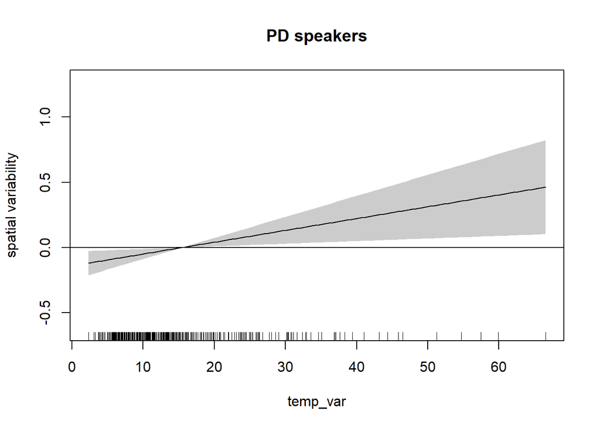

```r
plot(m10, select = 1, shade = T, main = "PD speakers", ylab = "spatial variability")
abline(h=0)
```

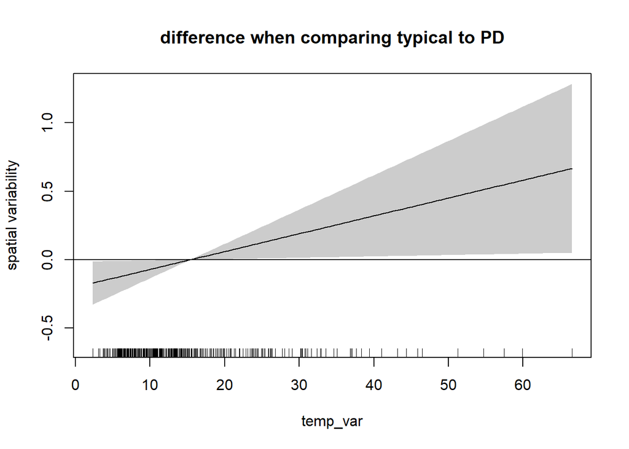

```r
plot(m10, select = 2, shade = T, main = "difference when comparing typical to PD", ylab = "spatial variability")
abline(h=0)
```

What if we split the smooth over temp_var separate for segO?

```r
summary(m11 <- bam(spat_var_bivariate ~ segO + s(temp_var) + s(temp_var, by = segO) + s(temp_var, by = groupO) + groupO + s(temp_var, subj, bs = "fs", m=1, k = 4) + s(temp_var, subj, by = segO, bs = "fs", m=1, k = 4), data = df, family =Gamma(link=log), discrete = T, nthreads = 10))
```

```
##
## Family: Gamma
## Link function: log
##
## Formula:
## spat_var_bivariate ~ segO + s(temp_var) + s(temp_var, by = segO) +
##     s(temp_var, by = groupO) + groupO + s(temp_var, subj, bs = "fs",
##     m = 1, k = 4) + s(temp_var, subj, by = segO, bs = "fs", m = 1,
##     k = 4)
##
## Parametric coefficients:
##               Estimate Std. Error t value Pr(>|t|)
## (Intercept)   -0.44089    0.04878  -9.039  < 2e-16 ***
## segOK          0.17929    0.06313   2.840  0.00481 **
## segOT         -0.14731    0.06156  -2.393  0.01730 *
## groupOtypical  0.41918    0.06436   6.513 2.92e-10 ***
## ---
## Signif. codes:  0 '***' 0.001 '**' 0.01 '*' 0.05 '.' 0.1 ' ' 1
##
## Approximate significance of smooth terms:
##                              edf  Ref.df      F  p-value
## s(temp_var)                1.000   1.000 14.874  0.00014 ***
## s(temp_var):segOK          1.000   1.000  4.332  0.03821 *
## s(temp_var):segOT          1.000   1.000  5.347  0.02140 *
## s(temp_var):groupOtypical  1.704   2.056  2.863  0.05403 .
## s(temp_var,subj)          21.681 159.000  0.223 3.83e-05 ***
## s(temp_var,subj):segOK    29.113 119.000  0.563  < 2e-16 ***
## s(temp_var,subj):segOT    23.550 127.000  0.522  < 2e-16 ***
## ---
## Signif. codes:  0 '***' 0.001 '**' 0.01 '*' 0.05 '.' 0.1 ' ' 1
##
## R-sq.(adj) =  0.514   Deviance explained =   64%
## fREML =  203.2  Scale est. = 0.11331   n = 397
```

Yes, /p/ shows a different pattern for /k/ and /t/ in the PD group.

Visualize:

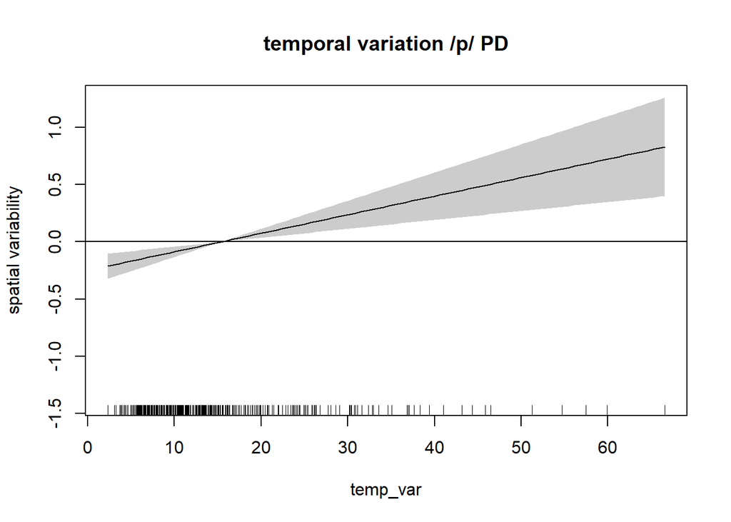

```r
plot(m11, select = 1, main = "temporal variation /p/ PD", ylab = "spatial variability", shade = T)
abline(h=0)
```

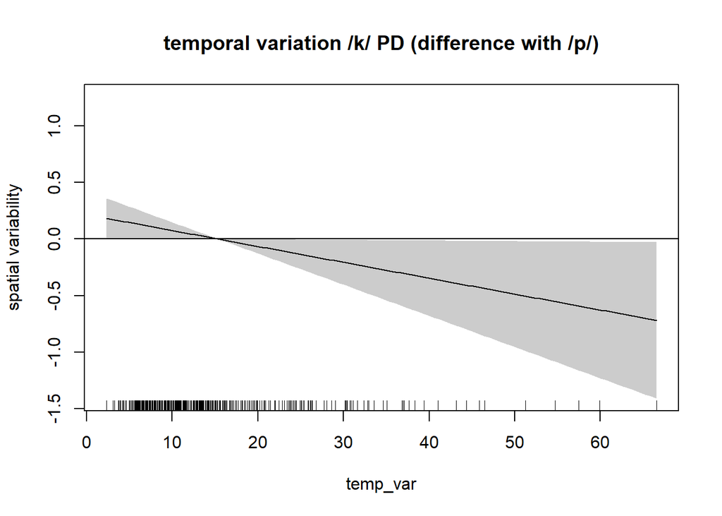

```r
plot(m11, select = 2, main = "temporal variation /k/ PD (difference with /p/)", ylab = "spatial variability", shade = T)
abline(h=0)
```

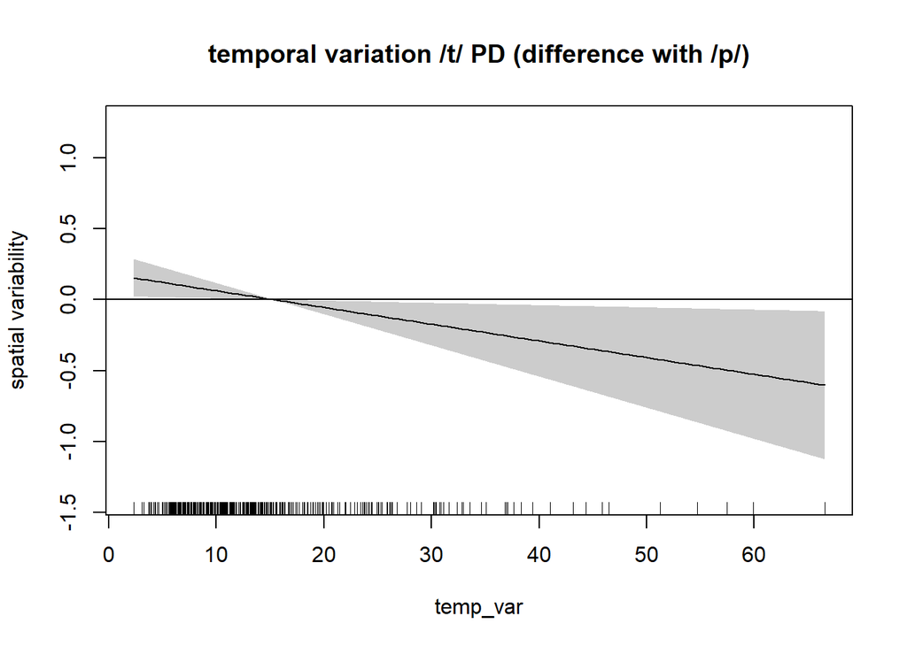

```r
plot(m11, select = 3, main = "temporal variation /t/ PD (difference with /p/)", ylab = "spatial variability", shade = T)
abline(h=0)
```

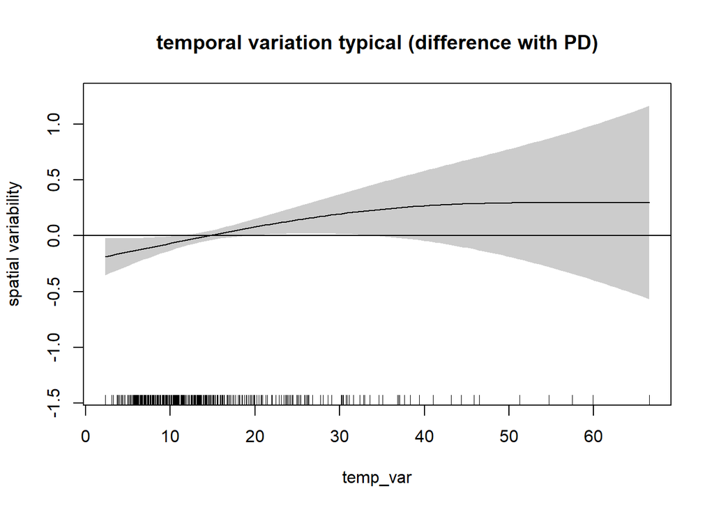

```r
plot(m11, select = 4, main = "temporal variation typical (difference with PD)", ylab = "spatial variability", shade = T)
abline(h=0)
```

What about typicals?

```r
summary(m12 <- bam(spat_var_bivariate ~ segO + s(temp_var) + s(temp_var, by = segO) + typicalP_O + typicalTK_O + typicalK_O + s(temp_var, by = typicalP_O) + s(temp_var, by = typicalTK_O) + s(temp_var, by = typicalK_O) + s(temp_var, subj, bs = "fs", m=1, k = 4) + s(temp_var, subj, by = segO, bs = "fs", m=1, k = 4), data = df, family =Gamma(link=log), discrete = T, nthreads = 10))
```

```
##
## Family: Gamma
## Link function: log
##
## Formula:
## spat_var_bivariate ~ segO + s(temp_var) + s(temp_var, by = segO) +
##     typicalP_O + typicalTK_O + typicalK_O + s(temp_var, by = typicalP_O) +
##     s(temp_var, by = typicalTK_O) + s(temp_var, by = typicalK_O) +
##     s(temp_var, subj, bs = "fs", m = 1, k = 4) + s(temp_var,
##     subj, by = segO, bs = "fs", m = 1, k = 4)
##
## Parametric coefficients:
##              Estimate Std. Error t value Pr(>|t|)
## (Intercept)  -0.44147    0.05301  -8.328 2.63e-15 ***
## segOK         0.16831    0.08964   1.878 0.061359 .
## segOT        -0.14851    0.09398  -1.580 0.115093
## typicalP_O1   0.36123    0.07739   4.668 4.53e-06 ***
## typicalTK_O1  0.43949    0.11936   3.682 0.000273 ***
## typicalK_O1   0.05674    0.15771   0.360 0.719281
## ---
## Signif. codes:  0 '***' 0.001 '**' 0.01 '*' 0.05 '.' 0.1 ' ' 1
##
## Approximate significance of smooth terms:
##                            edf Ref.df      F  p-value
## s(temp_var)               1.00      1 20.997 6.89e-06 ***
## s(temp_var):segOK         1.00      1 12.245 0.000534 ***
## s(temp_var):segOT         1.00      1  7.688 0.005894 **
## s(temp_var):typicalP_O1   1.00      1  0.158 0.691298
## s(temp_var):typicalTK_O1  1.00      1  3.998 0.046411 *
## s(temp_var):typicalK_O1   1.00      1  2.497 0.115054
## s(temp_var,subj)         21.52    159  0.229 2.21e-05 ***
## s(temp_var,subj):segOK   26.79    117  0.516  < 2e-16 ***
## s(temp_var,subj):segOT   25.04    127  0.544  < 2e-16 ***
## ---
## Signif. codes:  0 '***' 0.001 '**' 0.01 '*' 0.05 '.' 0.1 ' ' 1
##
## R-sq.(adj) =  0.529   Deviance explained = 64.9%
## fREML = 202.58  Scale est. = 0.11081   n = 397
```

For typicals, K does not differ from TK, so we take K out.

New model:

```r
summary(m13 <- bam(spat_var_bivariate ~ segO + s(temp_var) + s(temp_var, by = segO) + typicalP_O + typicalTK_O + s(temp_var, by = typicalP_O) + s(temp_var, by = typicalTK_O) + s(temp_var, subj, bs = "fs", m=1, k = 4) + s(temp_var, subj, by = segO, bs = "fs", m=1, k = 4), data = df, family =Gamma(link=log), discrete = T, nthreads = 10))
```

```
##
## Family: Gamma
## Link function: log
##
## Formula:
## spat_var_bivariate ~ segO + s(temp_var) + s(temp_var, by = segO) +
##     typicalP_O + typicalTK_O + s(temp_var, by = typicalP_O) +
##     s(temp_var, by = typicalTK_O) + s(temp_var, subj, bs = "fs",
##     m = 1, k = 4) + s(temp_var, subj, by = segO, bs = "fs", m = 1,
##     k = 4)
##
## Parametric coefficients:
##              Estimate Std. Error t value Pr(>|t|)
## (Intercept)  -0.44238    0.05317  -8.320 2.82e-15 ***
## segOK         0.17241    0.08036   2.145   0.0327 *
## segOT        -0.14828    0.08242  -1.799   0.0730 .
## typicalP_O1   0.35896    0.07709   4.657 4.77e-06 ***
## typicalTK_O1  0.46351    0.08896   5.210 3.44e-07 ***
## ---
## Signif. codes:  0 '***' 0.001 '**' 0.01 '*' 0.05 '.' 0.1 ' ' 1
##
## Approximate significance of smooth terms:
##                            edf Ref.df      F  p-value
## s(temp_var)               1.00      1 22.390 3.51e-06 ***
## s(temp_var):segOK         1.00      1 10.593 0.001260 **
## s(temp_var):segOT         1.00      1 11.214 0.000912 ***
## s(temp_var):typicalP_O1   1.00      1  0.211 0.646483
## s(temp_var):typicalTK_O1  1.00      1 13.012 0.000361 ***
## s(temp_var,subj)         20.52    159  0.225 1.43e-05 ***
## s(temp_var,subj):segOK   27.73    119  0.526  < 2e-16 ***
## s(temp_var,subj):segOT   28.23    129  0.559  < 2e-16 ***
## ---
## Signif. codes:  0 '***' 0.001 '**' 0.01 '*' 0.05 '.' 0.1 ' ' 1
##
## R-sq.(adj) =  0.532   Deviance explained = 65.3%
## fREML = 201.78  Scale est. = 0.10969   n = 397
```

Visualize:

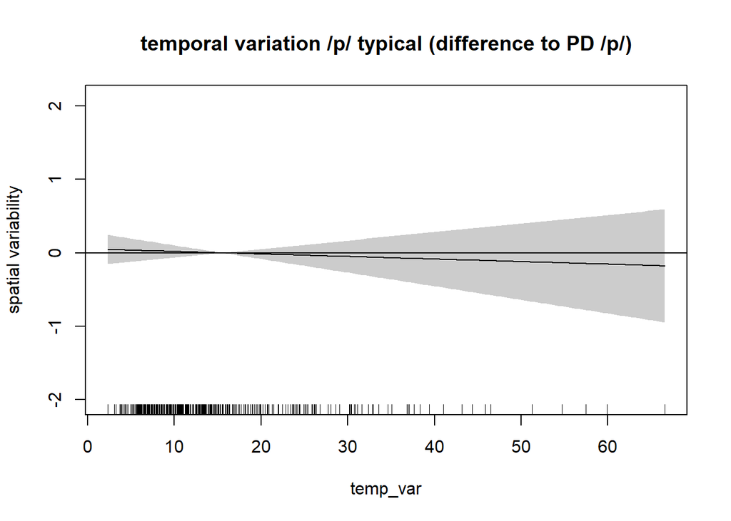

```r
plot(m13, select = 4, main = "temporal variation /p/ typical (difference to PD /p/)", ylab = "spatial variability", shade = T)
abline(0,0)
```

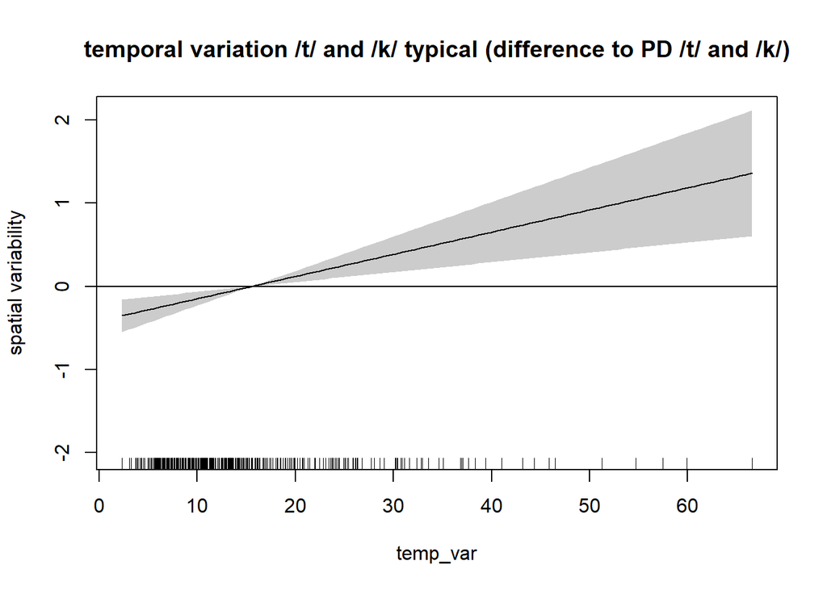

```r
plot(m13, select = 5, main = "temporal variation /t/ and /k/ typical (difference to PD /t/ and /k/)", ylab = "spatial variability", shade = T)
abline(0,0)
```

/p/ is comparable, but /t/ and /k/ show a steeper slope.

Check whether we can add another predictor instead of peakvel2target (including appropriate random smooths, compare based on R-squared)

```r
summary(m14Stiffness2target <- bam(spat_var_bivariate ~ s(mean.stiffness2target) + segO + s(temp_var) + s(temp_var, by = segO) + typicalP_O + typicalTK_O + s(temp_var, by = typicalP_O) + s(temp_var, by = typicalTK_O) + s(temp_var, subj, bs = "fs", m=1, k = 4) + s(temp_var, subj, by = segO, bs = "fs", m=1, k = 4), data = df, family =Gamma(link=log), discrete = T, nthreads = 10))
```

```
##
## Family: Gamma
## Link function: log
##
## Formula:
## spat_var_bivariate ~ s(mean.stiffness2target) + segO + s(temp_var) +
##     s(temp_var, by = segO) + typicalP_O + typicalTK_O + s(temp_var,
##     by = typicalP_O) + s(temp_var, by = typicalTK_O) + s(temp_var,
##     subj, bs = "fs", m = 1, k = 4) + s(temp_var, subj, by = segO,
##     bs = "fs", m = 1, k = 4)
##
## Parametric coefficients:
##              Estimate Std. Error t value Pr(>|t|)
## (Intercept)  -0.44401    0.05372  -8.265 4.13e-15 ***
## segOK         0.16349    0.08187   1.997   0.0467 *
## segOT        -0.14968    0.08262  -1.812   0.0710 .
## typicalP_O1   0.36148    0.07740   4.670 4.48e-06 ***
## typicalTK_O1  0.46744    0.08935   5.231 3.10e-07 ***
## ---
## Signif. codes:  0 '***' 0.001 '**' 0.01 '*' 0.05 '.' 0.1 ' ' 1
##
## Approximate significance of smooth terms:
##                            edf Ref.df      F  p-value
## s(mean.stiffness2target)  1.00      1  0.471 0.492851
## s(temp_var)               1.00      1 22.362 3.56e-06 ***
## s(temp_var):segOK         1.00      1 10.480 0.001337 **
## s(temp_var):segOT         1.00      1 11.146 0.000945 ***
## s(temp_var):typicalP_O1   1.00      1  0.290 0.590679
## s(temp_var):typicalTK_O1  1.00      1 12.538 0.000460 ***
## s(temp_var,subj)         20.71    159  0.231 1.03e-05 ***
## s(temp_var,subj):segOK   27.21    119  0.492 8.37e-07 ***
## s(temp_var,subj):segOT   27.89    129  0.553  < 2e-16 ***
## ---
## Signif. codes:  0 '***' 0.001 '**' 0.01 '*' 0.05 '.' 0.1 ' ' 1
##
## R-sq.(adj) =   0.53   Deviance explained = 65.2%
## fREML = 204.47  Scale est. = 0.11007   n = 397
```

```r
summary(m14Dist2target <- bam(spat_var_bivariate ~ s(mean.dist2target) + segO + s(temp_var) + s(temp_var, by = segO) + typicalP_O + typicalTK_O + s(temp_var, by = typicalP_O) + s(temp_var, by = typicalTK_O) + s(temp_var, subj, bs = "fs", m=1, k = 4) + s(temp_var, subj, by = segO, bs = "fs", m=1, k = 4), data = df, family =Gamma(link=log), discrete = T, nthreads = 10))
```

```
##
## Family: Gamma
## Link function: log
##
## Formula:
## spat_var_bivariate ~ s(mean.dist2target) + segO + s(temp_var) +
##     s(temp_var, by = segO) + typicalP_O + typicalTK_O + s(temp_var,
##     by = typicalP_O) + s(temp_var, by = typicalTK_O) + s(temp_var,
##     subj, bs = "fs", m = 1, k = 4) + s(temp_var, subj, by = segO,
##     bs = "fs", m = 1, k = 4)
##
## Parametric coefficients:
##              Estimate Std. Error t value Pr(>|t|)
## (Intercept)  -0.45007    0.05354  -8.406 1.55e-15 ***
## segOK         0.18864    0.08052   2.343   0.0198 *
## segOT        -0.13471    0.08309  -1.621   0.1060
## typicalP_O1   0.34597    0.07776   4.449 1.20e-05 ***
## typicalTK_O1  0.46007    0.08810   5.222 3.24e-07 ***
## ---
## Signif. codes:  0 '***' 0.001 '**' 0.01 '*' 0.05 '.' 0.1 ' ' 1
##
## Approximate significance of smooth terms:
##                            edf Ref.df      F  p-value
## s(mean.dist2target)       1.00      1  1.128 0.288962
## s(temp_var)               1.00      1 23.482 2.54e-06 ***
## s(temp_var):segOK         1.00      1 10.883 0.001083 **
## s(temp_var):segOT         1.00      1 11.639 0.000731 ***
## s(temp_var):typicalP_O1   1.00      1  0.307 0.579764
## s(temp_var):typicalTK_O1  1.00      1 12.751 0.000413 ***
## s(temp_var,subj)         20.05    159  0.219 1.60e-05 ***
## s(temp_var,subj):segOK   27.12    119  0.494 7.47e-07 ***
## s(temp_var,subj):segOT   28.00    129  0.557  < 2e-16 ***
## ---
## Signif. codes:  0 '***' 0.001 '**' 0.01 '*' 0.05 '.' 0.1 ' ' 1
##
## R-sq.(adj) =  0.529   Deviance explained =   65%
## fREML = 204.22  Scale est. = 0.11035   n = 397
```

```r
summary(m14Time2target <- bam(spat_var_bivariate ~ s(mean.time2target) + segO + s(temp_var) + s(temp_var, by = segO) + typicalP_O + typicalTK_O + s(temp_var, by = typicalP_O) + s(temp_var, by = typicalTK_O) + s(temp_var, subj, bs = "fs", m=1, k = 4) + s(temp_var, subj, by = segO, bs = "fs", m=1, k = 4), data = df, family =Gamma(link=log), discrete = T, nthreads = 10))
```

```
##
## Family: Gamma
## Link function: log
##
## Formula:
## spat_var_bivariate ~ s(mean.time2target) + segO + s(temp_var) +
##     s(temp_var, by = segO) + typicalP_O + typicalTK_O + s(temp_var,
##     by = typicalP_O) + s(temp_var, by = typicalTK_O) + s(temp_var,
##     subj, bs = "fs", m = 1, k = 4) + s(temp_var, subj, by = segO,
##     bs = "fs", m = 1, k = 4)
##
## Parametric coefficients:
##              Estimate Std. Error t value Pr(>|t|)
## (Intercept)  -0.43823    0.05357  -8.180 7.41e-15 ***
## segOK         0.16150    0.08149   1.982   0.0484 *
## segOT        -0.15422    0.08257  -1.868   0.0627 .
## typicalP_O1   0.36166    0.07814   4.629 5.42e-06 ***
## typicalTK_O1  0.47400    0.09035   5.246 2.89e-07 ***
## ---
## Signif. codes:  0 '***' 0.001 '**' 0.01 '*' 0.05 '.' 0.1 ' ' 1
##
## Approximate significance of smooth terms:
##                            edf Ref.df      F  p-value
## s(mean.time2target)       1.00      1  0.240 0.624426
## s(temp_var)               1.00      1 22.141 3.96e-06 ***
## s(temp_var):segOK         1.00      1 10.467 0.001346 **
## s(temp_var):segOT         1.00      1 11.130 0.000952 ***
## s(temp_var):typicalP_O1   1.00      1  0.267 0.605648
## s(temp_var):typicalTK_O1  1.00      1 12.531 0.000462 ***
## s(temp_var,subj)         20.91    159  0.233 1.04e-05 ***
## s(temp_var,subj):segOK   27.36    119  0.495 7.91e-07 ***
## s(temp_var,subj):segOT   28.12    129  0.557  < 2e-16 ***
## ---
## Signif. codes:  0 '***' 0.001 '**' 0.01 '*' 0.05 '.' 0.1 ' ' 1
##
## R-sq.(adj) =  0.531   Deviance explained = 65.3%
## fREML = 204.02  Scale est. = 0.10973   n = 397
```

```r
summary(m14Gestdur <- bam(spat_var_bivariate ~ s(mean.gest.dur) + segO + s(temp_var) + s(temp_var, by = segO) + typicalP_O + typicalTK_O + s(temp_var, by = typicalP_O) + s(temp_var, by = typicalTK_O) + s(temp_var, subj, bs = "fs", m=1, k = 4) + s(temp_var, subj, by = segO, bs = "fs", m=1, k = 4), data = df, family =Gamma(link=log), discrete = T, nthreads = 10))
```

```
##
## Family: Gamma
## Link function: log
##
## Formula:
## spat_var_bivariate ~ s(mean.gest.dur) + segO + s(temp_var) +
##     s(temp_var, by = segO) + typicalP_O + typicalTK_O + s(temp_var,
##     by = typicalP_O) + s(temp_var, by = typicalTK_O) + s(temp_var,
##     subj, bs = "fs", m = 1, k = 4) + s(temp_var, subj, by = segO,
##     bs = "fs", m = 1, k = 4)
##
## Parametric coefficients:
##              Estimate Std. Error t value Pr(>|t|)
## (Intercept)  -0.44397    0.05353  -8.294 3.40e-15 ***
## segOK         0.16408    0.08069   2.033   0.0429 *
## segOT        -0.15273    0.08260  -1.849   0.0654 .
## typicalP_O1   0.36395    0.07772   4.683 4.24e-06 ***
## typicalTK_O1  0.47264    0.08960   5.275 2.50e-07 ***
## ---
## Signif. codes:  0 '***' 0.001 '**' 0.01 '*' 0.05 '.' 0.1 ' ' 1
##
## Approximate significance of smooth terms:
##                            edf Ref.df      F  p-value
## s(mean.gest.dur)          1.00      1  0.542 0.462079
## s(temp_var)               1.00      1 21.859 4.54e-06 ***
## s(temp_var):segOK         1.00      1 10.407 0.001389 **
## s(temp_var):segOT         1.00      1 10.968 0.001036 **
## s(temp_var):typicalP_O1   1.00      1  0.283 0.595403
## s(temp_var):typicalTK_O1  1.00      1 12.261 0.000531 ***
## s(temp_var,subj)         21.19    159  0.235 1.05e-05 ***
## s(temp_var,subj):segOK   27.23    119  0.494  < 2e-16 ***
## s(temp_var,subj):segOT   27.96    129  0.555  < 2e-16 ***
## ---
## Signif. codes:  0 '***' 0.001 '**' 0.01 '*' 0.05 '.' 0.1 ' ' 1
##
## R-sq.(adj) =  0.532   Deviance explained = 65.3%
## fREML = 204.29  Scale est. = 0.10968   n = 397
```

```r
summary(m14speed <- bam(spat_var_bivariate ~ s(mean.speed2target) + segO + s(temp_var) + s(temp_var, by = segO) + typicalP_O + typicalTK_O + s(temp_var, by = typicalP_O) + s(temp_var, by = typicalTK_O) + s(temp_var, subj, bs = "fs", m=1, k = 4) + s(temp_var, subj, by = segO, bs = "fs", m=1, k = 4), data = df, family =Gamma(link=log), discrete = T, nthreads = 10))
```

```
##
## Family: Gamma
## Link function: log
##
## Formula:
## spat_var_bivariate ~ s(mean.speed2target) + segO + s(temp_var) +
##     s(temp_var, by = segO) + typicalP_O + typicalTK_O + s(temp_var,
##     by = typicalP_O) + s(temp_var, by = typicalTK_O) + s(temp_var,
##     subj, bs = "fs", m = 1, k = 4) + s(temp_var, subj, by = segO,
##     bs = "fs", m = 1, k = 4)
##
## Parametric coefficients:
##              Estimate Std. Error t value Pr(>|t|)
## (Intercept)  -0.43402    0.05330  -8.143 9.47e-15 ***
## segOK         0.19748    0.08235   2.398   0.0171 *
## segOT        -0.12916    0.08315  -1.553   0.1213
## typicalP_O1   0.31988    0.07967   4.015 7.46e-05 ***
## typicalTK_O1  0.41881    0.08690   4.820 2.25e-06 ***
## ---
## Signif. codes:  0 '***' 0.001 '**' 0.01 '*' 0.05 '.' 0.1 ' ' 1
##
## Approximate significance of smooth terms:
##                             edf  Ref.df      F  p-value
## s(mean.speed2target)      3.644   4.395  1.934 0.105035
## s(temp_var)               1.000   1.000 21.205 6.23e-06 ***
## s(temp_var):segOK         1.000   1.000  9.659 0.002058 **
## s(temp_var):segOT         1.000   1.000 10.737 0.001169 **
## s(temp_var):typicalP_O1   1.000   1.000  0.212 0.645831
## s(temp_var):typicalTK_O1  1.000   1.000 12.153 0.000561 ***
## s(temp_var,subj)         21.345 159.000  0.221 2.25e-05 ***
## s(temp_var,subj):segOK   25.437 119.000  0.446 1.47e-06 ***
## s(temp_var,subj):segOT   25.996 129.000  0.503  < 2e-16 ***
## ---
## Signif. codes:  0 '***' 0.001 '**' 0.01 '*' 0.05 '.' 0.1 ' ' 1
##
## R-sq.(adj) =  0.532   Deviance explained = 65.3%
## fREML = 203.11  Scale est. = 0.11032   n = 397
```

```r
summary(m14pace <- bam(spat_var_bivariate ~ s(pace) + segO + s(temp_var) + s(temp_var, by = segO) + typicalP_O + typicalTK_O + s(temp_var, by = typicalP_O) + s(temp_var, by = typicalTK_O) + s(temp_var, subj, bs = "fs", m=1, k = 4) + s(temp_var, subj, by = segO, bs = "fs", m=1, k = 4), data = df, family =Gamma(link=log), discrete = T, nthreads = 10))
```

```
##
## Family: Gamma
## Link function: log
##
## Formula:
## spat_var_bivariate ~ s(pace) + segO + s(temp_var) + s(temp_var,
##     by = segO) + typicalP_O + typicalTK_O + s(temp_var, by = typicalP_O) +
##     s(temp_var, by = typicalTK_O) + s(temp_var, subj, bs = "fs",
##     m = 1, k = 4) + s(temp_var, subj, by = segO, bs = "fs", m = 1,
##     k = 4)
##
## Parametric coefficients:
##              Estimate Std. Error t value Pr(>|t|)
## (Intercept)  -0.43804    0.05366  -8.164 8.22e-15 ***
## segOK         0.15703    0.08116   1.935   0.0539 .
## segOT        -0.15652    0.08252  -1.897   0.0588 .
## typicalP_O1   0.36136    0.07763   4.655 4.81e-06 ***
## typicalTK_O1  0.47298    0.08910   5.308 2.11e-07 ***
## ---
## Signif. codes:  0 '***' 0.001 '**' 0.01 '*' 0.05 '.' 0.1 ' ' 1
##
## Approximate significance of smooth terms:
##                            edf Ref.df      F  p-value
## s(pace)                   1.00      1  0.875 0.350363
## s(temp_var)               1.00      1 22.179 3.88e-06 ***
## s(temp_var):segOK         1.00      1 10.480 0.001337 **
## s(temp_var):segOT         1.00      1 11.033 0.001001 **
## s(temp_var):typicalP_O1   1.00      1  0.312 0.576599
## s(temp_var):typicalTK_O1  1.00      1 12.433 0.000485 ***
## s(temp_var,subj)         20.67    159  0.230 1.07e-05 ***
## s(temp_var,subj):segOK   27.10    119  0.490 8.42e-07 ***
## s(temp_var,subj):segOT   27.67    129  0.550  < 2e-16 ***
## ---
## Signif. codes:  0 '***' 0.001 '**' 0.01 '*' 0.05 '.' 0.1 ' ' 1
##
## R-sq.(adj) =   0.53   Deviance explained = 65.1%
## fREML = 203.91  Scale est. = 0.11019   n = 397
```

```r
summary(m14Accphase <- bam(spat_var_bivariate ~ s(mean.dur.accphase) + segO + s(temp_var) + s(temp_var, by = segO) + typicalP_O + typicalTK_O + s(temp_var, by = typicalP_O) + s(temp_var, by = typicalTK_O) + s(temp_var, subj, bs = "fs", m=1, k = 4) + s(temp_var, subj, by = segO, bs = "fs", m=1, k = 4), data = df, family =Gamma(link=log), discrete = T, nthreads = 10))
```

```
##
## Family: Gamma
## Link function: log
##
## Formula:
## spat_var_bivariate ~ s(mean.dur.accphase) + segO + s(temp_var) +
##     s(temp_var, by = segO) + typicalP_O + typicalTK_O + s(temp_var,
##     by = typicalP_O) + s(temp_var, by = typicalTK_O) + s(temp_var,
##     subj, bs = "fs", m = 1, k = 4) + s(temp_var, subj, by = segO,
##     bs = "fs", m = 1, k = 4)
##
## Parametric coefficients:
##              Estimate Std. Error t value Pr(>|t|)
## (Intercept)  -0.44250    0.05437  -8.138 9.71e-15 ***
## segOK         0.16475    0.07924   2.079   0.0384 *
## segOT        -0.14027    0.08180  -1.715   0.0874 .
## typicalP_O1   0.36651    0.07865   4.660 4.69e-06 ***
## typicalTK_O1  0.47573    0.08973   5.302 2.18e-07 ***
## ---
## Signif. codes:  0 '***' 0.001 '**' 0.01 '*' 0.05 '.' 0.1 ' ' 1
##
## Approximate significance of smooth terms:
##                             edf  Ref.df      F  p-value
## s(mean.dur.accphase)      1.885   2.288  1.197 0.320207
## s(temp_var)               1.000   1.000 22.504 3.32e-06 ***
## s(temp_var):segOK         1.000   1.000 10.664 0.001214 **
## s(temp_var):segOT         1.000   1.000 11.366 0.000842 ***
## s(temp_var):typicalP_O1   1.000   1.000  0.388 0.534077
## s(temp_var):typicalTK_O1  1.000   1.000 12.188 0.000551 ***
## s(temp_var,subj)         21.161 159.000  0.239 6.96e-06 ***
## s(temp_var,subj):segOK   25.839 119.000  0.420 8.61e-06 ***
## s(temp_var,subj):segOT   26.796 129.000  0.526  < 2e-16 ***
## ---
## Signif. codes:  0 '***' 0.001 '**' 0.01 '*' 0.05 '.' 0.1 ' ' 1
##
## R-sq.(adj) =  0.528   Deviance explained = 64.9%
## fREML = 203.65  Scale est. = 0.11074   n = 397
```

```r
summary(m14Decphase <- bam(spat_var_bivariate ~ s(mean.dur.decphase) + segO + s(temp_var) + s(temp_var, by = segO) + typicalP_O + typicalTK_O + s(temp_var, by = typicalP_O) + s(temp_var, by = typicalTK_O) + s(temp_var, subj, bs = "fs", m=1, k = 4) + s(temp_var, subj, by = segO, bs = "fs", m=1, k = 4), data = df, family =Gamma(link=log), discrete = T, nthreads = 10))
```

```
##
## Family: Gamma
## Link function: log
##
## Formula:
## spat_var_bivariate ~ s(mean.dur.decphase) + segO + s(temp_var) +
##     s(temp_var, by = segO) + typicalP_O + typicalTK_O + s(temp_var,
##     by = typicalP_O) + s(temp_var, by = typicalTK_O) + s(temp_var,
##     subj, bs = "fs", m = 1, k = 4) + s(temp_var, subj, by = segO,
##     bs = "fs", m = 1, k = 4)
##
## Parametric coefficients:
##              Estimate Std. Error t value Pr(>|t|)
## (Intercept)  -0.44650    0.05424  -8.232 5.19e-15 ***
## segOK         0.17769    0.08239   2.157   0.0318 *
## segOT        -0.14338    0.08322  -1.723   0.0859 .
## typicalP_O1   0.35905    0.07725   4.648 4.97e-06 ***
## typicalTK_O1  0.45708    0.08977   5.091 6.17e-07 ***
## ---
## Signif. codes:  0 '***' 0.001 '**' 0.01 '*' 0.05 '.' 0.1 ' ' 1
##
## Approximate significance of smooth terms:
##                            edf Ref.df      F  p-value
## s(mean.dur.decphase)      1.00      1  0.000 0.993486
## s(temp_var)               1.00      1 22.409 3.48e-06 ***
## s(temp_var):segOK         1.00      1 10.578 0.001270 **
## s(temp_var):segOT         1.00      1 11.210 0.000914 ***
## s(temp_var):typicalP_O1   1.00      1  0.214 0.644153
## s(temp_var):typicalTK_O1  1.00      1 12.871 0.000388 ***
## s(temp_var,subj)         20.34    159  0.226 1.23e-05 ***
## s(temp_var,subj):segOK   27.62    119  0.522  < 2e-16 ***
## s(temp_var,subj):segOT   27.91    129  0.553  < 2e-16 ***
## ---
## Signif. codes:  0 '***' 0.001 '**' 0.01 '*' 0.05 '.' 0.1 ' ' 1
##
## R-sq.(adj) =   0.53   Deviance explained = 65.2%
## fREML = 204.26  Scale est. = 0.11007   n = 397
```

No significant predictors.

Check if there’s a group difference:

```r
summary(m15Stiffness2target <- bam(spat_var_bivariate ~ s(mean.stiffness2target) + s(mean.stiffness2target, by = groupO) + segO + s(temp_var) + s(temp_var, by = segO) + typicalP_O + typicalTK_O + s(temp_var, by = typicalP_O) + s(temp_var, by = typicalTK_O) + s(temp_var, subj, bs = "fs", m=1, k = 4) + s(temp_var, subj, by = segO, bs = "fs", m=1, k = 4), data = df, family =Gamma(link=log), discrete = T, nthreads = 10))
```

```
##
## Family: Gamma
## Link function: log
##
## Formula:
## spat_var_bivariate ~ s(mean.stiffness2target) + s(mean.stiffness2target,
##     by = groupO) + segO + s(temp_var) + s(temp_var, by = segO) +
##     typicalP_O + typicalTK_O + s(temp_var, by = typicalP_O) +
##     s(temp_var, by = typicalTK_O) + s(temp_var, subj, bs = "fs",
##     m = 1, k = 4) + s(temp_var, subj, by = segO, bs = "fs", m = 1,
##     k = 4)
##
## Parametric coefficients:
##              Estimate Std. Error t value Pr(>|t|)
## (Intercept)  -0.44053    0.05453  -8.079 1.48e-14 ***
## segOK         0.15548    0.08244   1.886   0.0602 .
## segOT        -0.15787    0.08339  -1.893   0.0593 .
## typicalP_O1   0.35579    0.07912   4.497 9.77e-06 ***
## typicalTK_O1  0.47323    0.09057   5.225 3.21e-07 ***
## ---
## Signif. codes:  0 '***' 0.001 '**' 0.01 '*' 0.05 '.' 0.1 ' ' 1
##
## Approximate significance of smooth terms:
##                                          edf Ref.df      F  p-value
## s(mean.stiffness2target)                1.00      1  0.706 0.401476
## s(mean.stiffness2target):groupOtypical  1.00      1  0.233 0.629841
## s(temp_var)                             1.00      1 22.306 3.66e-06 ***
## s(temp_var):segOK                       1.00      1 10.484 0.001335 **
## s(temp_var):segOT                       1.00      1 11.127 0.000955 ***
## s(temp_var):typicalP_O1                 1.00      1  0.268 0.605053
## s(temp_var):typicalTK_O1                1.00      1 12.507 0.000468 ***
## s(temp_var,subj)                       21.30    159  0.243 6.99e-06 ***
## s(temp_var,subj):segOK                 27.02    119  0.484 9.87e-07 ***
## s(temp_var,subj):segOT                 27.61    129  0.539  < 2e-16 ***
## ---
## Signif. codes:  0 '***' 0.001 '**' 0.01 '*' 0.05 '.' 0.1 ' ' 1
##
## R-sq.(adj) =  0.531   Deviance explained = 65.4%
## fREML = 206.04  Scale est. = 0.11003   n = 397
```

```r
summary(m15Dist2target <- bam(spat_var_bivariate ~ s(mean.dist2target) + s(mean.dist2target, by = groupO) + segO + s(temp_var) + s(temp_var, by = segO) + typicalP_O + typicalTK_O + s(temp_var, by = typicalP_O) + s(temp_var, by = typicalTK_O) + s(temp_var, subj, bs = "fs", m=1, k = 4) + s(temp_var, subj, by = segO, bs = "fs", m=1, k = 4), data = df, family =Gamma(link=log), discrete = T, nthreads = 10))
```

```
##
## Family: Gamma
## Link function: log
##
## Formula:
## spat_var_bivariate ~ s(mean.dist2target) + s(mean.dist2target,
##     by = groupO) + segO + s(temp_var) + s(temp_var, by = segO) +
##     typicalP_O + typicalTK_O + s(temp_var, by = typicalP_O) +
##     s(temp_var, by = typicalTK_O) + s(temp_var, subj, bs = "fs",
##     m = 1, k = 4) + s(temp_var, subj, by = segO, bs = "fs", m = 1,
##     k = 4)
##
## Parametric coefficients:
##              Estimate Std. Error t value Pr(>|t|)
## (Intercept)  -0.44926    0.05449  -8.245 4.72e-15 ***
## segOK         0.19106    0.08158   2.342   0.0198 *
## segOT        -0.13221    0.08402  -1.574   0.1166
## typicalP_O1   0.35072    0.08132   4.313 2.17e-05 ***
## typicalTK_O1  0.45704    0.08985   5.087 6.32e-07 ***
## ---
## Signif. codes:  0 '***' 0.001 '**' 0.01 '*' 0.05 '.' 0.1 ' ' 1
##
## Approximate significance of smooth terms:
##                                     edf Ref.df      F  p-value
## s(mean.dist2target)                1.00      1  0.853 0.356513
## s(mean.dist2target):groupOtypical  1.00      1  0.107 0.743665
## s(temp_var)                        1.00      1 23.159 2.93e-06 ***
## s(temp_var):segOK                  1.00      1 11.055 0.000990 ***
## s(temp_var):segOT                  1.00      1 11.802 0.000672 ***
## s(temp_var):typicalP_O1            1.00      1  0.369 0.543934
## s(temp_var):typicalTK_O1           1.00      1 12.556 0.000456 ***
## s(temp_var,subj)                  20.28    159  0.226 1.22e-05 ***
## s(temp_var,subj):segOK            26.76    119  0.476 1.20e-06 ***
## s(temp_var,subj):segOT            27.74    129  0.545  < 2e-16 ***
## ---
## Signif. codes:  0 '***' 0.001 '**' 0.01 '*' 0.05 '.' 0.1 ' ' 1
##
## R-sq.(adj) =  0.528   Deviance explained = 65.1%
## fREML =  205.9  Scale est. = 0.11066   n = 397
```

```r
summary(m15Time2target <- bam(spat_var_bivariate ~ s(mean.time2target) + s(mean.time2target, by = groupO) + segO + s(temp_var) + s(temp_var, by = segO) + typicalP_O + typicalTK_O + s(temp_var, by = typicalP_O) + s(temp_var, by = typicalTK_O) + s(temp_var, subj, bs = "fs", m=1, k = 4) + s(temp_var, subj, by = segO, bs = "fs", m=1, k = 4), data = df, family =Gamma(link=log), discrete = T, nthreads = 10))
```

```
##
## Family: Gamma
## Link function: log
##
## Formula:
## spat_var_bivariate ~ s(mean.time2target) + s(mean.time2target,
##     by = groupO) + segO + s(temp_var) + s(temp_var, by = segO) +
##     typicalP_O + typicalTK_O + s(temp_var, by = typicalP_O) +
##     s(temp_var, by = typicalTK_O) + s(temp_var, subj, bs = "fs",
##     m = 1, k = 4) + s(temp_var, subj, by = segO, bs = "fs", m = 1,
##     k = 4)
##
## Parametric coefficients:
##              Estimate Std. Error t value Pr(>|t|)
## (Intercept)  -0.44761    0.05497  -8.143 9.62e-15 ***
## segOK         0.16808    0.08252   2.037   0.0425 *
## segOT        -0.14779    0.08338  -1.772   0.0773 .
## typicalP_O1   0.35110    0.08023   4.376 1.66e-05 ***
## typicalTK_O1  0.45557    0.09114   4.999 9.69e-07 ***
## ---
## Signif. codes:  0 '***' 0.001 '**' 0.01 '*' 0.05 '.' 0.1 ' ' 1
##
## Approximate significance of smooth terms:
##                                      edf  Ref.df      F  p-value
## s(mean.time2target)                1.328   1.529  0.296 0.601395
## s(mean.time2target):groupOtypical  1.000   1.000  0.360 0.548822
## s(temp_var)                        1.000   1.000 22.011 4.22e-06 ***
## s(temp_var):segOK                  1.000   1.000 10.476 0.001340 **
## s(temp_var):segOT                  1.000   1.000 11.032 0.001003 **
## s(temp_var):typicalP_O1            1.000   1.000  0.192 0.661493
## s(temp_var):typicalTK_O1           1.000   1.000 12.705 0.000423 ***
## s(temp_var,subj)                  21.333 159.000  0.242 7.23e-06 ***
## s(temp_var,subj):segOK            27.151 119.000  0.492 7.95e-07 ***
## s(temp_var,subj):segOT            27.577 129.000  0.540  < 2e-16 ***
## ---
## Signif. codes:  0 '***' 0.001 '**' 0.01 '*' 0.05 '.' 0.1 ' ' 1
##
## R-sq.(adj) =  0.533   Deviance explained = 65.5%
## fREML = 206.16  Scale est. = 0.10972   n = 397
```

```r
summary(m15Gestdur <- bam(spat_var_bivariate ~ s(mean.gest.dur) + s(mean.gest.dur, by = groupO) + segO + s(temp_var) + s(temp_var, by = segO) + typicalP_O + typicalTK_O + s(temp_var, by = typicalP_O) + s(temp_var, by = typicalTK_O) + s(temp_var, subj, bs = "fs", m=1, k = 4) + s(temp_var, subj, by = segO, bs = "fs", m=1, k = 4), data = df, family =Gamma(link=log), discrete = T, nthreads = 10))
```

```
##
## Family: Gamma
## Link function: log
##
## Formula:
## spat_var_bivariate ~ s(mean.gest.dur) + s(mean.gest.dur, by = groupO) +
##     segO + s(temp_var) + s(temp_var, by = segO) + typicalP_O +
##     typicalTK_O + s(temp_var, by = typicalP_O) + s(temp_var,
##     by = typicalTK_O) + s(temp_var, subj, bs = "fs", m = 1, k = 4) +
##     s(temp_var, subj, by = segO, bs = "fs", m = 1, k = 4)
##
## Parametric coefficients:
##              Estimate Std. Error t value Pr(>|t|)
## (Intercept)  -0.44391    0.05447  -8.149 9.31e-15 ***
## segOK         0.15763    0.08111   1.943   0.0529 .
## segOT        -0.15886    0.08298  -1.915   0.0565 .
## typicalP_O1   0.35804    0.07937   4.511 9.18e-06 ***
## typicalTK_O1  0.47599    0.09083   5.241 2.98e-07 ***
## ---
## Signif. codes:  0 '***' 0.001 '**' 0.01 '*' 0.05 '.' 0.1 ' ' 1
##
## Approximate significance of smooth terms:
##                                  edf Ref.df      F  p-value
## s(mean.gest.dur)                1.00      1  0.980 0.322881
## s(mean.gest.dur):groupOtypical  1.00      1  0.425 0.514824
## s(temp_var)                     1.00      1 21.559 5.30e-06 ***
## s(temp_var):segOK               1.00      1 10.361 0.001424 **
## s(temp_var):segOT               1.00      1 10.877 0.001087 **
## s(temp_var):typicalP_O1         1.00      1  0.213 0.644611
## s(temp_var):typicalTK_O1        1.00      1 12.410 0.000492 ***
## s(temp_var,subj)               22.27    159  0.253 5.89e-06 ***
## s(temp_var,subj):segOK         27.18    119  0.492  < 2e-16 ***
## s(temp_var,subj):segOT         27.87    129  0.545  < 2e-16 ***
## ---
## Signif. codes:  0 '***' 0.001 '**' 0.01 '*' 0.05 '.' 0.1 ' ' 1
##
## R-sq.(adj) =  0.534   Deviance explained = 65.7%
## fREML = 205.89  Scale est. = 0.109     n = 397
```

```r
summary(m15Speed <- bam(spat_var_bivariate ~ s(mean.peakvel2target) + s(mean.peakvel2target, by = groupO)  + segO + s(temp_var) + s(temp_var, by = segO) + typicalP_O + typicalTK_O + s(temp_var, by = typicalP_O) + s(temp_var, by = typicalTK_O) + s(temp_var, subj, bs = "fs", m=1, k = 4) + s(temp_var, subj, by = segO, bs = "fs", m=1, k = 4), data = df, family =Gamma(link=log), discrete = T, nthreads = 10))
```

```
##
## Family: Gamma
## Link function: log
##
## Formula:
## spat_var_bivariate ~ s(mean.peakvel2target) + s(mean.peakvel2target,
##     by = groupO) + segO + s(temp_var) + s(temp_var, by = segO) +
##     typicalP_O + typicalTK_O + s(temp_var, by = typicalP_O) +
##     s(temp_var, by = typicalTK_O) + s(temp_var, subj, bs = "fs",
##     m = 1, k = 4) + s(temp_var, subj, by = segO, bs = "fs", m = 1,
##     k = 4)
##
## Parametric coefficients:
##              Estimate Std. Error t value Pr(>|t|)
## (Intercept)  -0.43281    0.05408  -8.003 2.47e-14 ***
## segOK         0.19144    0.08527   2.245 0.025471 *
## segOT        -0.13176    0.08530  -1.545 0.123457
## typicalP_O1   0.32329    0.08669   3.729 0.000228 ***
## typicalTK_O1  0.42603    0.09015   4.726 3.48e-06 ***
## ---
## Signif. codes:  0 '***' 0.001 '**' 0.01 '*' 0.05 '.' 0.1 ' ' 1
##
## Approximate significance of smooth terms:
##                                         edf  Ref.df      F  p-value
## s(mean.peakvel2target)                3.402   4.115  1.567 0.173445
## s(mean.peakvel2target):groupOtypical  1.000   1.000  0.000 0.992997
## s(temp_var)                           1.000   1.000 19.754 1.27e-05 ***
## s(temp_var):segOK                     1.000   1.000  9.404 0.002356 **
## s(temp_var):segOT                     1.000   1.000 10.444 0.001363 **
## s(temp_var):typicalP_O1               1.000   1.000  0.179 0.672517
## s(temp_var):typicalTK_O1              1.000   1.000 11.998 0.000608 ***
## s(temp_var,subj)                     21.734 159.000  0.230 1.51e-05 ***
## s(temp_var,subj):segOK               25.661 119.000  0.446 1.57e-06 ***
## s(temp_var,subj):segOT               25.822 129.000  0.499  < 2e-16 ***
## ---
## Signif. codes:  0 '***' 0.001 '**' 0.01 '*' 0.05 '.' 0.1 ' ' 1
##
## R-sq.(adj) =  0.532   Deviance explained = 65.4%
## fREML = 204.96  Scale est. = 0.11029   n = 397
```

```r
summary(m15Pace <- bam(spat_var_bivariate ~ s(pace) + s(pace, by = groupO) + segO + s(temp_var) + s(temp_var, by = segO) + typicalP_O + typicalTK_O + s(temp_var, by = typicalP_O) + s(temp_var, by = typicalTK_O) + s(temp_var, subj, bs = "fs", m=1, k = 4) + s(temp_var, subj, by = segO, bs = "fs", m=1, k = 4), data = df, family =Gamma(link=log), discrete = T, nthreads = 10))
```

```
##
## Family: Gamma
## Link function: log
##
## Formula:
## spat_var_bivariate ~ s(pace) + s(pace, by = groupO) + segO +
##     s(temp_var) + s(temp_var, by = segO) + typicalP_O + typicalTK_O +
##     s(temp_var, by = typicalP_O) + s(temp_var, by = typicalTK_O) +
##     s(temp_var, subj, bs = "fs", m = 1, k = 4) + s(temp_var,
##     subj, by = segO, bs = "fs", m = 1, k = 4)
##
## Parametric coefficients:
##              Estimate Std. Error t value Pr(>|t|)
## (Intercept)  -0.42859    0.05432  -7.889 5.33e-14 ***
## segOK         0.14154    0.08148   1.737   0.0834 .
## segOT        -0.17200    0.08310  -2.070   0.0393 *
## typicalP_O1   0.35214    0.08012   4.395 1.53e-05 ***
## typicalTK_O1  0.48636    0.09033   5.384 1.45e-07 ***
## ---
## Signif. codes:  0 '***' 0.001 '**' 0.01 '*' 0.05 '.' 0.1 ' ' 1
##
## Approximate significance of smooth terms:
##                            edf Ref.df      F  p-value
## s(pace)                   1.00      1  1.199 0.274291
## s(pace):groupOtypical     1.00      1  0.365 0.546350
## s(temp_var)               1.00      1 21.953 4.34e-06 ***
## s(temp_var):segOK         1.00      1 10.480 0.001338 **
## s(temp_var):segOT         1.00      1 10.950 0.001047 **
## s(temp_var):typicalP_O1   1.00      1  0.248 0.618786
## s(temp_var):typicalTK_O1  1.00      1 12.575 0.000452 ***
## s(temp_var,subj)         21.63    159  0.247 6.03e-06 ***
## s(temp_var,subj):segOK   27.09    119  0.487 8.74e-07 ***
## s(temp_var,subj):segOT   28.03    129  0.545  < 2e-16 ***
## ---
## Signif. codes:  0 '***' 0.001 '**' 0.01 '*' 0.05 '.' 0.1 ' ' 1
##
## R-sq.(adj) =  0.534   Deviance explained = 65.6%
## fREML = 205.54  Scale est. = 0.10932   n = 397
```

```r
summary(m15Accphase <- bam(spat_var_bivariate ~ s(mean.dur.accphase) + s(mean.dur.accphase, by = groupO) + segO + s(temp_var) + s(temp_var, by = segO) + typicalP_O + typicalTK_O + s(temp_var, by = typicalP_O) + s(temp_var, by = typicalTK_O) + s(temp_var, subj, bs = "fs", m=1, k = 4) + s(temp_var, subj, by = segO, bs = "fs", m=1, k = 4), data = df, family =Gamma(link=log), discrete = T, nthreads = 10))
```

```
##
## Family: Gamma
## Link function: log
##
## Formula:
## spat_var_bivariate ~ s(mean.dur.accphase) + s(mean.dur.accphase,
##     by = groupO) + segO + s(temp_var) + s(temp_var, by = segO) +
##     typicalP_O + typicalTK_O + s(temp_var, by = typicalP_O) +
##     s(temp_var, by = typicalTK_O) + s(temp_var, subj, bs = "fs",
##     m = 1, k = 4) + s(temp_var, subj, by = segO, bs = "fs", m = 1,
##     k = 4)
##
## Parametric coefficients:
##              Estimate Std. Error t value Pr(>|t|)
## (Intercept)  -0.43676    0.05485  -7.963 3.22e-14 ***
## segOK         0.15771    0.07908   1.994   0.0470 *
## segOT        -0.14706    0.08172  -1.800   0.0729 .
## typicalP_O1   0.35280    0.08494   4.153 4.24e-05 ***
## typicalTK_O1  0.47135    0.09468   4.979 1.07e-06 ***
## ---
## Signif. codes:  0 '***' 0.001 '**' 0.01 '*' 0.05 '.' 0.1 ' ' 1
##
## Approximate significance of smooth terms:
##                                       edf  Ref.df      F  p-value
## s(mean.dur.accphase)                2.135   2.624  1.017 0.395294
## s(mean.dur.accphase):groupOtypical  1.000   1.000  0.145 0.704110
## s(temp_var)                         1.000   1.000 22.356 3.57e-06 ***
## s(temp_var):segOK                   1.000   1.000 10.773 0.001147 **
## s(temp_var):segOT                   1.000   1.000 11.302 0.000871 ***
## s(temp_var):typicalP_O1             1.000   1.000  0.356 0.551204
## s(temp_var):typicalTK_O1            1.000   1.000 12.223 0.000541 ***
## s(temp_var,subj)                   21.731 159.000  0.250 4.60e-06 ***
## s(temp_var,subj):segOK             25.656 119.000  0.416 8.91e-06 ***
## s(temp_var,subj):segOT             26.688 129.000  0.515  < 2e-16 ***
## ---
## Signif. codes:  0 '***' 0.001 '**' 0.01 '*' 0.05 '.' 0.1 ' ' 1
##
## R-sq.(adj) =  0.529   Deviance explained = 65.2%
## fREML = 205.01  Scale est. = 0.11035   n = 397
```

```r
summary(m15Decphase <- bam(spat_var_bivariate ~ s(mean.dur.decphase )+ s(mean.dur.decphase, by = groupO) + segO + s(temp_var) + s(temp_var, by = segO) + typicalP_O + typicalTK_O + s(temp_var, by = typicalP_O) + s(temp_var, by = typicalTK_O) + s(temp_var, subj, bs = "fs", m=1, k = 4) + s(temp_var, subj, by = segO, bs = "fs", m=1, k = 4), data = df, family =Gamma(link=log), discrete = T, nthreads = 10))
```

```
##
## Family: Gamma
## Link function: log
##
## Formula:
## spat_var_bivariate ~ s(mean.dur.decphase) + s(mean.dur.decphase,
##     by = groupO) + segO + s(temp_var) + s(temp_var, by = segO) +
##     typicalP_O + typicalTK_O + s(temp_var, by = typicalP_O) +
##     s(temp_var, by = typicalTK_O) + s(temp_var, subj, bs = "fs",
##     m = 1, k = 4) + s(temp_var, subj, by = segO, bs = "fs", m = 1,
##     k = 4)
##
## Parametric coefficients:
##              Estimate Std. Error t value Pr(>|t|)
## (Intercept)  -0.44862    0.05580  -8.040 1.95e-14 ***
## segOK         0.17561    0.08365   2.099   0.0366 *
## segOT        -0.14399    0.08385  -1.717   0.0870 .
## typicalP_O1   0.34202    0.08099   4.223 3.18e-05 ***
## typicalTK_O1  0.44770    0.09089   4.926 1.37e-06 ***
## ---
## Signif. codes:  0 '***' 0.001 '**' 0.01 '*' 0.05 '.' 0.1 ' ' 1
##
## Approximate significance of smooth terms:
##                                      edf Ref.df      F  p-value
## s(mean.dur.decphase)                1.00      1  0.232 0.630561
## s(mean.dur.decphase):groupOtypical  1.00      1  0.630 0.428075
## s(temp_var)                         1.00      1 21.517 5.41e-06 ***
## s(temp_var):segOK                   1.00      1 10.324 0.001452 **
## s(temp_var):segOT                   1.00      1 10.913 0.001068 **
## s(temp_var):typicalP_O1             1.00      1  0.097 0.755166
## s(temp_var):typicalTK_O1            1.00      1 13.051 0.000354 ***
## s(temp_var,subj)                   21.75    159  0.247 6.93e-06 ***
## s(temp_var,subj):segOK             27.70    119  0.525  < 2e-16 ***
## s(temp_var,subj):segOT             27.54    129  0.537  < 2e-16 ***
## ---
## Signif. codes:  0 '***' 0.001 '**' 0.01 '*' 0.05 '.' 0.1 ' ' 1
##
## R-sq.(adj) =  0.535   Deviance explained = 65.7%
## fREML = 205.94  Scale est. = 0.10934   n = 397
```

No significant group differences.

Add trial.no

```r
summary(m16 <- bam(spat_var_bivariate ~ s(trial.no) + segO + s(temp_var) + s(temp_var, by = segO) + typicalP_O + typicalTK_O + s(temp_var, by = typicalP_O) + s(temp_var, by = typicalTK_O) + s(temp_var, subj, bs = "fs", m=1, k = 4) + s(temp_var, subj, by = segO, bs = "fs", m=1, k = 4), data = df, family =Gamma(link=log), discrete = T, nthreads = 10))
```

```
##
## Family: Gamma
## Link function: log
##
## Formula:
## spat_var_bivariate ~ s(trial.no) + segO + s(temp_var) + s(temp_var,
##     by = segO) + typicalP_O + typicalTK_O + s(temp_var, by = typicalP_O) +
##     s(temp_var, by = typicalTK_O) + s(temp_var, subj, bs = "fs",
##     m = 1, k = 4) + s(temp_var, subj, by = segO, bs = "fs", m = 1,
##     k = 4)
##
## Parametric coefficients:
##              Estimate Std. Error t value Pr(>|t|)
## (Intercept)  -0.44831    0.05324  -8.420 1.46e-15 ***
## segOK         0.18049    0.08060   2.239   0.0258 *
## segOT        -0.14304    0.08225  -1.739   0.0830 .
## typicalP_O1   0.35175    0.07623   4.614 5.81e-06 ***
## typicalTK_O1  0.46089    0.08926   5.163 4.37e-07 ***
## ---
## Signif. codes:  0 '***' 0.001 '**' 0.01 '*' 0.05 '.' 0.1 ' ' 1
##
## Approximate significance of smooth terms:
##                             edf Ref.df      F  p-value
## s(trial.no)               3.201   3.91  1.243 0.336432
## s(temp_var)               1.000   1.00 23.474 2.54e-06 ***
## s(temp_var):segOK         1.000   1.00 11.624 0.000738 ***
## s(temp_var):segOT         1.000   1.00 11.832 0.000663 ***
## s(temp_var):typicalP_O1   1.000   1.00  0.206 0.650079
## s(temp_var):typicalTK_O1  1.000   1.00 14.390 0.000179 ***
## s(temp_var,subj)         19.485 159.00  0.221 1.11e-05 ***
## s(temp_var,subj):segOK   28.658 119.00  0.559  < 2e-16 ***
## s(temp_var,subj):segOT   28.861 129.00  0.564  < 2e-16 ***
## ---
## Signif. codes:  0 '***' 0.001 '**' 0.01 '*' 0.05 '.' 0.1 ' ' 1
##
## R-sq.(adj) =  0.544   Deviance explained = 66.2%
## fREML = 204.63  Scale est. = 0.10745   n = 397
```

No.

Add random smooths over trial.no per seg?

```r
summary(m16Random <- bam(spat_var_bivariate ~ s(trial.no) + segO + s(temp_var) + s(temp_var, by = segO) + typicalP_O + typicalTK_O + s(temp_var, by = typicalP_O) + s(temp_var, by = typicalTK_O) + s(trial.no, subj, bs = "fs", m=1, k = 4) + s(trial.no, subj, by = segO, bs = "fs", m=1, k = 4) + s(temp_var, subj, bs = "fs", m=1, k = 4) + s(temp_var, subj, by = segO, bs = "fs", m=1, k = 4), data = df, family =Gamma(link=log), discrete = T, nthreads = 10))
```

```
##
## Family: Gamma
## Link function: log
##
## Formula:
## spat_var_bivariate ~ s(trial.no) + segO + s(temp_var) + s(temp_var,
##     by = segO) + typicalP_O + typicalTK_O + s(temp_var, by = typicalP_O) +
##     s(temp_var, by = typicalTK_O) + s(trial.no, subj, bs = "fs",
##     m = 1, k = 4) + s(trial.no, subj, by = segO, bs = "fs", m = 1,
##     k = 4) + s(temp_var, subj, bs = "fs", m = 1, k = 4) + s(temp_var,
##     subj, by = segO, bs = "fs", m = 1, k = 4)
##
## Parametric coefficients:
##              Estimate Std. Error t value Pr(>|t|)
## (Intercept)  -0.44827    0.05241  -8.552 7.60e-16 ***
## segOK         0.17629    0.07822   2.254   0.0250 *
## segOT        -0.16371    0.07672  -2.134   0.0337 *
## typicalP_O1   0.34836    0.07435   4.686 4.34e-06 ***
## typicalTK_O1  0.45665    0.08735   5.228 3.33e-07 ***
## ---
## Signif. codes:  0 '***' 0.001 '**' 0.01 '*' 0.05 '.' 0.1 ' ' 1
##
## Approximate significance of smooth terms:
##                             edf  Ref.df      F  p-value
## s(trial.no)               3.512   4.252  1.334 0.232351
## s(temp_var)               1.000   1.000 28.652 2.91e-07 ***
## s(temp_var):segOK         1.000   1.000 12.091 0.000586 ***
## s(temp_var):segOT         1.000   1.000 13.479 0.000288 ***
## s(temp_var):typicalP_O1   1.000   1.000  0.284 0.594645
## s(temp_var):typicalTK_O1  1.113   1.177 11.784 0.000304 ***
## s(trial.no,subj)          9.823 159.000  0.084 1.69e-06 ***
## s(trial.no,subj):segOK   15.809 120.000  0.176 1.48e-06 ***
## s(trial.no,subj):segOT   33.093 131.000  0.430 8.70e-06 ***
## s(temp_var,subj)          9.823 159.000  0.084 1.69e-06 ***
## s(temp_var,subj):segOK   20.226 119.000  0.269 1.05e-06 ***
## s(temp_var,subj):segOT   10.633 127.000  0.119  < 2e-16 ***
## ---
## Signif. codes:  0 '***' 0.001 '**' 0.01 '*' 0.05 '.' 0.1 ' ' 1
##
## R-sq.(adj) =  0.583   Deviance explained = 71.8%
## fREML = 201.58  Scale est. = 0.095443  n = 397
```

Yes.

Separate for group?

```r
summary(m16group <- bam(spat_var_bivariate ~ s(trial.no) + s(trial.no, by = groupO) + segO + s(temp_var) + s(temp_var, by = segO) + typicalP_O + typicalTK_O + s(temp_var, by = typicalP_O) + s(temp_var, by = typicalTK_O) + s(trial.no, subj, bs = "fs", m=1, k = 4) + s(trial.no, subj, by = segO, bs = "fs", m=1, k = 4) + s(temp_var, subj, bs = "fs", m=1, k = 4) + s(temp_var, subj, by = segO, bs = "fs", m=1, k = 4), data = df, family =Gamma(link=log), discrete = T, nthreads = 10))
```

```
##
## Family: Gamma
## Link function: log
##
## Formula:
## spat_var_bivariate ~ s(trial.no) + s(trial.no, by = groupO) +
##     segO + s(temp_var) + s(temp_var, by = segO) + typicalP_O +
##     typicalTK_O + s(temp_var, by = typicalP_O) + s(temp_var,
##     by = typicalTK_O) + s(trial.no, subj, bs = "fs", m = 1, k = 4) +
##     s(trial.no, subj, by = segO, bs = "fs", m = 1, k = 4) + s(temp_var,
##     subj, bs = "fs", m = 1, k = 4) + s(temp_var, subj, by = segO,
##     bs = "fs", m = 1, k = 4)
##
## Parametric coefficients:
##              Estimate Std. Error t value Pr(>|t|)
## (Intercept)  -0.44901    0.05250  -8.553 7.13e-16 ***
## segOK         0.17766    0.07851   2.263   0.0244 *
## segOT        -0.16555    0.07699  -2.150   0.0324 *
## typicalP_O1   0.35266    0.07443   4.738 3.39e-06 ***
## typicalTK_O1  0.46333    0.08700   5.326 2.03e-07 ***
## ---
## Signif. codes:  0 '***' 0.001 '**' 0.01 '*' 0.05 '.' 0.1 ' ' 1
##
## Approximate significance of smooth terms:
##                              edf  Ref.df      F  p-value
## s(trial.no)                3.566   4.325  1.697 0.163739
## s(trial.no):groupOtypical  1.000   1.000  2.487 0.115905
## s(temp_var)                1.000   1.000 25.784 9.60e-07 ***
## s(temp_var):segOK          1.000   1.000 11.451 0.000813 ***
## s(temp_var):segOT          1.000   1.000 12.596 0.000451 ***
## s(temp_var):typicalP_O1    1.000   1.000  0.048 0.826799
## s(temp_var):typicalTK_O1   1.079   1.127 13.396 0.000155 ***
## s(trial.no,subj)           9.587 159.000  0.081 2.52e-06 ***
## s(trial.no,subj):segOK    11.609 120.000  0.131  < 2e-16 ***
## s(trial.no,subj):segOT    31.426 131.000  0.394 1.70e-05 ***
## s(temp_var,subj)           9.588 159.000  0.081 2.52e-06 ***
## s(temp_var,subj):segOK    20.739 119.000  0.282 2.50e-06 ***
## s(temp_var,subj):segOT    10.585 127.000  0.118  < 2e-16 ***
## ---
## Signif. codes:  0 '***' 0.001 '**' 0.01 '*' 0.05 '.' 0.1 ' ' 1
##
## R-sq.(adj) =  0.576   Deviance explained = 70.7%
## fREML = 202.78  Scale est. = 0.097629  n = 397
```

No, so we take trial.no out.

Add block (first or second)?

```r
summary(m17 <- bam(spat_var_bivariate ~ block + segO + s(temp_var) + s(temp_var, by = segO) + typicalP_O + typicalTK_O + s(temp_var, by = typicalP_O) + s(temp_var, by = typicalTK_O) + s(temp_var, subj, bs = "fs", m=1, k = 4) + s(temp_var, subj, by = segO, bs = "fs", m=1, k = 4), data = df, family =Gamma(link=log), discrete = T, nthreads = 10))
```

```
##
## Family: Gamma
## Link function: log
##
## Formula:
## spat_var_bivariate ~ block + segO + s(temp_var) + s(temp_var,
##     by = segO) + typicalP_O + typicalTK_O + s(temp_var, by = typicalP_O) +
##     s(temp_var, by = typicalTK_O) + s(temp_var, subj, bs = "fs",
##     m = 1, k = 4) + s(temp_var, subj, by = segO, bs = "fs", m = 1,
##     k = 4)
##
## Parametric coefficients:
##              Estimate Std. Error t value Pr(>|t|)
## (Intercept)  -0.42504    0.05641  -7.535 5.39e-13 ***
## blockDDK2    -0.03071    0.03536  -0.869   0.3858
## segOK         0.17209    0.08034   2.142   0.0330 *
## segOT        -0.14846    0.08211  -1.808   0.0716 .
## typicalP_O1   0.35663    0.07724   4.617 5.70e-06 ***
## typicalTK_O1  0.46213    0.08876   5.206 3.52e-07 ***
## ---
## Signif. codes:  0 '***' 0.001 '**' 0.01 '*' 0.05 '.' 0.1 ' ' 1
##
## Approximate significance of smooth terms:
##                            edf Ref.df      F  p-value
## s(temp_var)               1.00      1 21.576 5.24e-06 ***
## s(temp_var):segOK         1.00      1 10.584 0.001267 **
## s(temp_var):segOT         1.00      1 11.160 0.000938 ***
## s(temp_var):typicalP_O1   1.00      1  0.225 0.635408
## s(temp_var):typicalTK_O1  1.00      1 12.908 0.000381 ***
## s(temp_var,subj)         20.67    159  0.227 1.40e-05 ***
## s(temp_var,subj):segOK   27.67    119  0.524  < 2e-16 ***
## s(temp_var,subj):segOT   27.41    129  0.545  < 2e-16 ***
## ---
## Signif. codes:  0 '***' 0.001 '**' 0.01 '*' 0.05 '.' 0.1 ' ' 1
##
## R-sq.(adj) =  0.533   Deviance explained = 65.1%
## fREML = 203.84  Scale est. = 0.10982   n = 397
```

No.

Add random slopes:

```r
summary(m17Slopes <- bam(spat_var_bivariate ~ block + segO + s(temp_var) + s(temp_var, by = segO) + typicalP_O + typicalTK_O + s(temp_var, by = typicalP_O) + s(temp_var, by = typicalTK_O) + s(block, subj, bs='re') + s(temp_var, subj, bs = "fs", m=1, k = 4) + s(temp_var, subj, by = segO, bs = "fs", m=1, k = 4), data = df, family =Gamma(link=log), discrete = T, nthreads = 10))
```

```
##
## Family: Gamma
## Link function: log
##
## Formula:
## spat_var_bivariate ~ block + segO + s(temp_var) + s(temp_var,
##     by = segO) + typicalP_O + typicalTK_O + s(temp_var, by = typicalP_O) +
##     s(temp_var, by = typicalTK_O) + s(block, subj, bs = "re") +
##     s(temp_var, subj, bs = "fs", m = 1, k = 4) + s(temp_var,
##     subj, by = segO, bs = "fs", m = 1, k = 4)
##
## Parametric coefficients:
##              Estimate Std. Error t value Pr(>|t|)
## (Intercept)  -0.42414    0.05646  -7.512 6.35e-13 ***
## blockDDK2    -0.03155    0.03631  -0.869   0.3856
## segOK         0.17104    0.08008   2.136   0.0335 *
## segOT        -0.14917    0.08191  -1.821   0.0695 .
## typicalP_O1   0.35608    0.07713   4.617 5.73e-06 ***
## typicalTK_O1  0.46262    0.08876   5.212 3.43e-07 ***
## ---
## Signif. codes:  0 '***' 0.001 '**' 0.01 '*' 0.05 '.' 0.1 ' ' 1
##
## Approximate significance of smooth terms:
##                             edf Ref.df      F  p-value
## s(temp_var)               1.000      1 21.801 4.68e-06 ***
## s(temp_var):segOK         1.000      1 10.686 0.001202 **
## s(temp_var):segOT         1.000      1 11.193 0.000923 ***
## s(temp_var):typicalP_O1   1.000      1  0.228 0.633301
## s(temp_var):typicalTK_O1  1.000      1 12.991 0.000365 ***
## s(block,subj)             2.996     79  0.040 0.100078
## s(temp_var,subj)         19.536    159  0.216 3.53e-05 ***
## s(temp_var,subj):segOK   27.643    119  0.530  < 2e-16 ***
## s(temp_var,subj):segOT   27.550    129  0.554  < 2e-16 ***
## ---
## Signif. codes:  0 '***' 0.001 '**' 0.01 '*' 0.05 '.' 0.1 ' ' 1
##
## R-sq.(adj) =  0.535   Deviance explained = 65.6%
## fREML =  203.8  Scale est. = 0.10899   n = 397
```

No.

Per group?

```r
summary(m17Group <- bam(spat_var_bivariate ~ block + block:groupO + segO + s(temp_var) + s(temp_var, by = segO) + typicalP_O + typicalTK_O + s(temp_var, by = typicalP_O) + s(temp_var, by = typicalTK_O) + s(temp_var, subj, bs = "fs", m=1, k = 4) + s(temp_var, subj, by = segO, bs = "fs", m=1, k = 4), data = df, family =Gamma(link=log), discrete = T, nthreads = 10))
```

```
##
## Family: Gamma
## Link function: log
##
## Formula:
## spat_var_bivariate ~ block + block:groupO + segO + s(temp_var) +
##     s(temp_var, by = segO) + typicalP_O + typicalTK_O + s(temp_var,
##     by = typicalP_O) + s(temp_var, by = typicalTK_O) + s(temp_var,
##     subj, bs = "fs", m = 1, k = 4) + s(temp_var, subj, by = segO,
##     bs = "fs", m = 1, k = 4)
##
## Parametric coefficients:
##                         Estimate Std. Error t value Pr(>|t|)
## (Intercept)             -0.39751    0.06037  -6.584 1.95e-10 ***
## blockDDK2               -0.08054    0.05352  -1.505   0.1334
## segOK                    0.17369    0.08021   2.165   0.0311 *
## segOT                   -0.14838    0.08178  -1.814   0.0706 .
## typicalP_O1              0.39914    0.08512   4.689 4.11e-06 ***
## typicalTK_O1             0.50106    0.09390   5.336 1.83e-07 ***
## blockDDK1:groupOtypical -0.08739    0.07144  -1.223   0.2222
## blockDDK2:groupOtypical  0.00000    0.00000      NA       NA
## ---
## Signif. codes:  0 '***' 0.001 '**' 0.01 '*' 0.05 '.' 0.1 ' ' 1
##
## Approximate significance of smooth terms:
##                            edf Ref.df      F  p-value
## s(temp_var)               1.00      1 20.244 9.97e-06 ***
## s(temp_var):segOK         1.00      1 10.535 0.001299 **
## s(temp_var):segOT         1.00      1 11.099 0.000968 ***
## s(temp_var):typicalP_O1   1.00      1  0.108 0.743134
## s(temp_var):typicalTK_O1  1.00      1 13.649 0.000261 ***
## s(temp_var,subj)         20.76    159  0.226 1.51e-05 ***
## s(temp_var,subj):segOK   27.26    119  0.511  < 2e-16 ***
## s(temp_var,subj):segOT   26.46    129  0.525  < 2e-16 ***
## ---
## Signif. codes:  0 '***' 0.001 '**' 0.01 '*' 0.05 '.' 0.1 ' ' 1
##
## Rank: 556/557
## R-sq.(adj) =  0.533   Deviance explained = 64.9%
## fREML = 205.04  Scale est. = 0.11072   n = 397
```

No difference.

Add gender?

```r
summary(m18 <- bam(spat_var_bivariate ~ gender + segO + s(temp_var) + s(temp_var, by = segO) + typicalP_O + typicalTK_O + s(temp_var, by = typicalP_O) + s(temp_var, by = typicalTK_O) + s(temp_var, subj, bs = "fs", m=1, k = 4) + s(temp_var, subj, by = segO, bs = "fs", m=1, k = 4), data = df, family =Gamma(link=log), discrete = T, nthreads = 10))
```

```
##
## Family: Gamma
## Link function: log
##
## Formula:
## spat_var_bivariate ~ gender + segO + s(temp_var) + s(temp_var,
##     by = segO) + typicalP_O + typicalTK_O + s(temp_var, by = typicalP_O) +
##     s(temp_var, by = typicalTK_O) + s(temp_var, subj, bs = "fs",
##     m = 1, k = 4) + s(temp_var, subj, by = segO, bs = "fs", m = 1,
##     k = 4)
##
## Parametric coefficients:
##              Estimate Std. Error t value Pr(>|t|)
## (Intercept)  -0.46224    0.07801  -5.925 8.31e-09 ***
## genderM       0.02510    0.07112   0.353   0.7244
## segOK         0.17341    0.08049   2.155   0.0320 *
## segOT        -0.14767    0.08285  -1.782   0.0757 .
## typicalP_O1   0.36033    0.07784   4.629 5.41e-06 ***
## typicalTK_O1  0.46551    0.08982   5.182 3.96e-07 ***
## ---
## Signif. codes:  0 '***' 0.001 '**' 0.01 '*' 0.05 '.' 0.1 ' ' 1
##
## Approximate significance of smooth terms:
##                            edf Ref.df      F  p-value
## s(temp_var)               1.00      1 22.369 3.55e-06 ***
## s(temp_var):segOK         1.00      1 10.691  0.00120 **
## s(temp_var):segOT         1.00      1 11.262  0.00089 ***
## s(temp_var):typicalP_O1   1.00      1  0.229  0.63254
## s(temp_var):typicalTK_O1  1.00      1 13.020  0.00036 ***
## s(temp_var,subj)         20.59    158  0.232 1.03e-05 ***
## s(temp_var,subj):segOK   27.65    119  0.523  < 2e-16 ***
## s(temp_var,subj):segOT   28.55    129  0.561  < 2e-16 ***
## ---
## Signif. codes:  0 '***' 0.001 '**' 0.01 '*' 0.05 '.' 0.1 ' ' 1
##
## R-sq.(adj) =  0.533   Deviance explained = 65.5%
## fREML = 203.43  Scale est. = 0.10915   n = 397
```

No.

Per group?

```r
summary(m18Group <- bam(spat_var_bivariate ~ gender + gender:groupO + groupO + segO + s(temp_var) + s(temp_var, by = segO) + typicalP_O + typicalTK_O + s(temp_var, by = typicalP_O) + s(temp_var, by = typicalTK_O) + s(temp_var, subj, bs = "fs", m=1, k = 4) + s(temp_var, subj, by = segO, bs = "fs", m=1, k = 4), data = df, family =Gamma(link=log), discrete = T, nthreads = 10))
```

```
##
## Family: Gamma
## Link function: log
##
## Formula:
## spat_var_bivariate ~ gender + gender:groupO + groupO + segO +
##     s(temp_var) + s(temp_var, by = segO) + typicalP_O + typicalTK_O +
##     s(temp_var, by = typicalP_O) + s(temp_var, by = typicalTK_O) +
##     s(temp_var, subj, bs = "fs", m = 1, k = 4) + s(temp_var,
##     subj, by = segO, bs = "fs", m = 1, k = 4)
##
## Parametric coefficients:
##                       Estimate Std. Error t value Pr(>|t|)
## (Intercept)           -0.50269    0.10452  -4.810 2.36e-06 ***
## genderM                0.07624    0.11227   0.679 0.497589
## groupOtypical          0.00000    0.00000      NA       NA
## segOK                  0.17643    0.08048   2.192 0.029112 *
## segOT                 -0.14456    0.08309  -1.740 0.082880 .
## typicalP_O1            0.42573    0.13670   3.114 0.002016 **
## typicalTK_O1           0.52759    0.13977   3.775 0.000192 ***
## genderM:groupOtypical -0.08634    0.14604  -0.591 0.554827
## ---
## Signif. codes:  0 '***' 0.001 '**' 0.01 '*' 0.05 '.' 0.1 ' ' 1
##
## Approximate significance of smooth terms:
##                            edf Ref.df      F  p-value
## s(temp_var)               1.00      1 23.031 3.10e-06 ***
## s(temp_var):segOK         1.00      1 10.891 0.001079 **
## s(temp_var):segOT         1.00      1 11.487 0.000792 ***
## s(temp_var):typicalP_O1   1.00      1  0.248 0.619039
## s(temp_var):typicalTK_O1  1.00      1 13.205 0.000327 ***
## s(temp_var,subj)         19.61    157  0.229 9.05e-06 ***
## s(temp_var,subj):segOK   27.47    119  0.512  < 2e-16 ***
## s(temp_var,subj):segOT   28.63    129  0.560  < 2e-16 ***
## ---
## Signif. codes:  0 '***' 0.001 '**' 0.01 '*' 0.05 '.' 0.1 ' ' 1
##
## Rank: 556/557
## R-sq.(adj) =  0.531   Deviance explained = 65.4%
## fREML = 204.47  Scale est. = 0.10977   n = 397
```

No difference.

Age?

```r
summary(m19 <- bam(spat_var_bivariate ~ s(age) + segO + s(temp_var) + s(temp_var, by = segO) + typicalP_O + typicalTK_O + s(temp_var, by = typicalP_O) + s(temp_var, by = typicalTK_O) + s(temp_var, subj, bs = "fs", m=1, k = 4) + s(temp_var, subj, by = segO, bs = "fs", m=1, k = 4), data = df, family =Gamma(link=log), discrete = T, nthreads = 10))
```

```
##
## Family: Gamma
## Link function: log
##
## Formula:
## spat_var_bivariate ~ s(age) + segO + s(temp_var) + s(temp_var,
##     by = segO) + typicalP_O + typicalTK_O + s(temp_var, by = typicalP_O) +
##     s(temp_var, by = typicalTK_O) + s(temp_var, subj, bs = "fs",
##     m = 1, k = 4) + s(temp_var, subj, by = segO, bs = "fs", m = 1,
##     k = 4)
##
## Parametric coefficients:
##              Estimate Std. Error t value Pr(>|t|)
## (Intercept)  -0.44001    0.05173  -8.506 7.66e-16 ***
## segOK         0.17270    0.07938   2.176   0.0303 *
## segOT        -0.14596    0.08160  -1.789   0.0746 .
## typicalP_O1   0.35482    0.07566   4.690 4.10e-06 ***
## typicalTK_O1  0.45449    0.08606   5.281 2.41e-07 ***
## ---
## Signif. codes:  0 '***' 0.001 '**' 0.01 '*' 0.05 '.' 0.1 ' ' 1
##
## Approximate significance of smooth terms:
##                            edf Ref.df      F  p-value
## s(age)                    1.00      1  4.219 0.040809 *
## s(temp_var)               1.00      1 20.666 8.11e-06 ***
## s(temp_var):segOK         1.00      1 10.439 0.001366 **
## s(temp_var):segOT         1.00      1 11.289 0.000877 ***
## s(temp_var):typicalP_O1   1.00      1  0.127 0.721867
## s(temp_var):typicalTK_O1  1.00      1 13.269 0.000316 ***
## s(temp_var,subj)         20.36    158  0.206 5.93e-05 ***
## s(temp_var,subj):segOK   26.98    119  0.494  < 2e-16 ***
## s(temp_var,subj):segOT   27.44    129  0.542  < 2e-16 ***
## ---
## Signif. codes:  0 '***' 0.001 '**' 0.01 '*' 0.05 '.' 0.1 ' ' 1
##
## R-sq.(adj) =  0.531   Deviance explained = 65.1%
## fREML = 202.37  Scale est. = 0.11014   n = 397
```

Yes, but note that is was not sign. in our earlier model comparison.

Check once more using select = T:

```r
summary(m19minAge <- bam(spat_var_bivariate ~  segO + s(temp_var) + s(temp_var, by = segO) + typicalP_O + typicalTK_O + s(temp_var, by = typicalP_O) + s(temp_var, by = typicalTK_O) + s(temp_var, subj, bs = "fs", m=1, k = 4) + s(temp_var, subj, by = segO, bs = "fs", m=1, k = 4), data = df, family =Gamma(link=log), select = T, discrete = T, nthreads = 10))
```

```
##
## Family: Gamma
## Link function: log
##
## Formula:
## spat_var_bivariate ~ segO + s(temp_var) + s(temp_var, by = segO) +
##     typicalP_O + typicalTK_O + s(temp_var, by = typicalP_O) +
##     s(temp_var, by = typicalTK_O) + s(temp_var, subj, bs = "fs",
##     m = 1, k = 4) + s(temp_var, subj, by = segO, bs = "fs", m = 1,
##     k = 4)
##
## Parametric coefficients:
##              Estimate Std. Error t value Pr(>|t|)
## (Intercept)  -0.44040    0.05303  -8.305 3.12e-15 ***
## segOK         0.17111    0.08089   2.115   0.0352 *
## segOT        -0.15017    0.08231  -1.824   0.0690 .
## typicalP_O1   0.35898    0.07562   4.747 3.15e-06 ***
## typicalTK_O1  0.45525    0.08912   5.108 5.69e-07 ***
## ---
## Signif. codes:  0 '***' 0.001 '**' 0.01 '*' 0.05 '.' 0.1 ' ' 1
##
## Approximate significance of smooth terms:
##                                edf Ref.df     F  p-value
## s(temp_var)              2.462e+00      9 3.135  < 2e-16 ***
## s(temp_var):segOK        8.905e-01      9 0.904 4.50e-05 ***
## s(temp_var):segOT        1.848e+00      9 0.998 0.000206 ***
## s(temp_var):typicalP_O1  1.651e-05      9 0.000 0.666214
## s(temp_var):typicalTK_O1 9.022e-01      9 1.014 3.61e-05 ***
## s(temp_var,subj)         2.124e+01    159 0.232 1.34e-05 ***
## s(temp_var,subj):segOK   2.831e+01    120 0.538  < 2e-16 ***
## s(temp_var,subj):segOT   2.570e+01    130 0.530  < 2e-16 ***
## ---
## Signif. codes:  0 '***' 0.001 '**' 0.01 '*' 0.05 '.' 0.1 ' ' 1
##
## R-sq.(adj) =  0.543   Deviance explained = 65.5%
## fREML = 200.11  Scale est. = 0.10974   n = 397
```

```r
summary(m19Age <- bam(spat_var_bivariate ~  s(age) + segO + s(temp_var) + s(temp_var, by = segO) + typicalP_O + typicalTK_O + s(temp_var, by = typicalP_O) + s(temp_var, by = typicalTK_O) + s(temp_var, subj, bs = "fs", m=1, k = 4) + s(temp_var, subj, by = segO, bs = "fs", m=1, k = 4), data = df, family =Gamma(link=log), select = T, discrete = T, nthreads = 10))
```

```
##
## Family: Gamma
## Link function: log
##
## Formula:
## spat_var_bivariate ~ s(age) + segO + s(temp_var) + s(temp_var,
##     by = segO) + typicalP_O + typicalTK_O + s(temp_var, by = typicalP_O) +
##     s(temp_var, by = typicalTK_O) + s(temp_var, subj, bs = "fs",
##     m = 1, k = 4) + s(temp_var, subj, by = segO, bs = "fs", m = 1,
##     k = 4)
##
## Parametric coefficients:
##              Estimate Std. Error t value Pr(>|t|)
## (Intercept)  -0.43795    0.05162  -8.485 8.88e-16 ***
## segOK         0.17156    0.08013   2.141   0.0331 *
## segOT        -0.15034    0.08162  -1.842   0.0664 .
## typicalP_O1   0.35430    0.07389   4.795 2.53e-06 ***
## typicalTK_O1  0.44840    0.08660   5.178 4.04e-07 ***
## ---
## Signif. codes:  0 '***' 0.001 '**' 0.01 '*' 0.05 '.' 0.1 ' ' 1
##
## Approximate significance of smooth terms:
##                                edf Ref.df     F  p-value
## s(age)                   7.489e-01      9 0.331 0.002973 **
## s(temp_var)              2.443e+00      9 2.998  < 2e-16 ***
## s(temp_var):segOK        8.900e-01      9 0.899 4.67e-05 ***
## s(temp_var):segOT        1.862e+00      9 1.026 0.000174 ***
## s(temp_var):typicalP_O1  2.029e-05      9 0.000 0.603658
## s(temp_var):typicalTK_O1 9.609e-01      9 1.038 2.92e-05 ***
## s(temp_var,subj)         2.082e+01    159 0.210 4.99e-05 ***
## s(temp_var,subj):segOK   2.781e+01    120 0.516  < 2e-16 ***
## s(temp_var,subj):segOT   2.498e+01    130 0.518  < 2e-16 ***
## ---
## Signif. codes:  0 '***' 0.001 '**' 0.01 '*' 0.05 '.' 0.1 ' ' 1
##
## R-sq.(adj) =  0.542   Deviance explained = 65.3%
## fREML = 199.38  Scale est. = 0.11004   n = 397
```

```r
compareML(m19minAge, m19Age)
```

```
## m19minAge: spat_var_bivariate ~ segO + s(temp_var) + s(temp_var, by = segO) +
##     typicalP_O + typicalTK_O + s(temp_var, by = typicalP_O) +
##     s(temp_var, by = typicalTK_O) + s(temp_var, subj, bs = "fs",
##     m = 1, k = 4) + s(temp_var, subj, by = segO, bs = "fs", m = 1,
##     k = 4)
##
## m19Age: spat_var_bivariate ~ s(age) + segO + s(temp_var) + s(temp_var,
##     by = segO) + typicalP_O + typicalTK_O + s(temp_var, by = typicalP_O) +
##     s(temp_var, by = typicalTK_O) + s(temp_var, subj, bs = "fs",
##     m = 1, k = 4) + s(temp_var, subj, by = segO, bs = "fs", m = 1,
##     k = 4)
##
## Chi-square test of fREML scores
## -----
##       Model    Score Edf Difference    Df p.value Sig.
## 1 m19minAge 200.1088  21
## 2    m19Age 199.3805  23      0.728 2.000   0.483
##
## AIC difference: -2.74, model m19minAge has lower AIC.
```

No need to include age.

# 7 Final model

Final model, fit with fREML:

```r
mFinalExploratory <- m13
```

## 7.1 Check assumptions

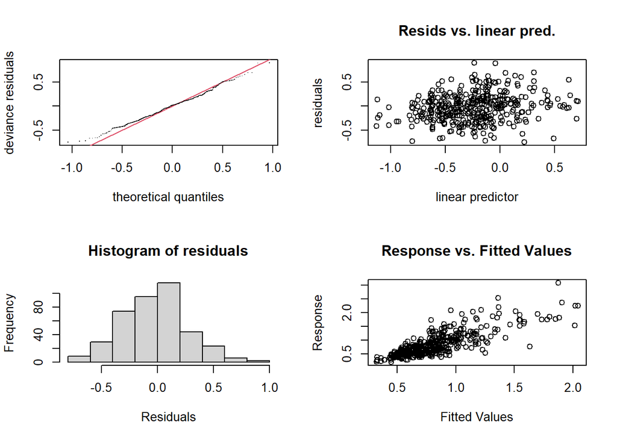

```
##
## Method: fREML   Optimizer: perf chol
## $grad
##  [1] -2.612166e-06 -3.665633e-06 -2.198498e-06 -3.426982e-06 -3.102573e-06
##  [6] -7.732784e-07  3.777639e-07  1.247765e-06  5.370973e-07 -3.105481e-06
## [11] -6.295063e-06  5.562276e-05
##
## $hess
##            [,1]          [,2]          [,3]          [,4]          [,5]
##    2.612154e-06 -8.230999e-13 -6.166333e-12 -1.084370e-11 -5.787053e-12
##   -8.230999e-13  3.665616e-06 -1.221073e-12  4.818226e-13 -6.864100e-12
##   -6.166333e-12 -1.221073e-12  2.198492e-06  7.322794e-13 -1.004947e-11
##   -1.084370e-11  4.818226e-13  7.322794e-13  3.426972e-06 -3.900760e-12
##   -5.787053e-12 -6.864100e-12 -1.004947e-11 -3.900760e-12  3.102569e-06
##   -1.888199e-07 -5.074388e-08  1.075622e-07  2.775544e-07 -1.221333e-07
##   -1.217456e-07 -5.073640e-08 -9.339134e-08  1.502624e-07  4.445200e-08
##   -3.510895e-08 -7.132266e-07  1.985800e-07 -1.407919e-07 -3.313039e-07
##   -7.233553e-08 -7.837854e-07  2.533144e-07 -4.441581e-07  6.267888e-07
##   -2.543809e-07 -1.583429e-07  4.943133e-07 -2.574773e-08  1.769484e-07
##   -8.081696e-08  6.351807e-08 -2.150094e-06 -2.094748e-07  1.101737e-06
## d -5.247830e-07 -5.142921e-07 -2.126797e-06 -4.941630e-06 -2.883099e-06
##            [,6]          [,7]          [,8]          [,9]         [,10]
##   -1.888199e-07 -1.217456e-07 -3.510895e-08 -7.233553e-08 -2.543809e-07
##   -5.074388e-08 -5.073640e-08 -7.132266e-07 -7.837854e-07 -1.583429e-07
##    1.075622e-07 -9.339134e-08  1.985800e-07  2.533144e-07  4.943133e-07
##    2.775544e-07  1.502624e-07 -1.407919e-07 -4.441581e-07 -2.574773e-08
##   -1.221333e-07  4.445200e-08 -3.313039e-07  6.267888e-07  1.769484e-07
##    1.902554e-01  1.671387e-01  1.329417e-01  4.295071e-03  1.026355e-01
##    1.671387e-01  3.674702e+00  6.452265e-02  4.416276e-01  9.227711e-03
##    1.329417e-01  6.452265e-02  1.343956e+00  3.425400e-01  4.181788e-02
##    4.295071e-03  4.416276e-01  3.425400e-01  5.028722e+00  2.118687e-02
##    1.026355e-01  9.227711e-03  4.181788e-02  2.118687e-02  3.796257e-01
##   -1.231274e-02  4.330636e-02 -1.834554e-02  6.654830e-02 -1.607496e-01
## d -2.043933e+00 -8.213763e+00 -4.431112e+00 -9.432148e+00 -2.807673e+00
##           [,11]         [,12]
##   -8.081696e-08 -5.247830e-07
##    6.351807e-08 -5.142921e-07
##   -2.150094e-06 -2.126797e-06
##   -2.094748e-07 -4.941630e-06
##    1.101737e-06 -2.883099e-06
##   -1.231274e-02 -2.043933e+00
##    4.330636e-02 -8.213763e+00
##   -1.834554e-02 -4.431112e+00
##    6.654830e-02 -9.432148e+00
##   -1.607496e-01 -2.807673e+00
##    7.371448e+00 -1.130779e+01
## d -1.130779e+01  1.934999e+02
##
## Model rank =  554 / 554
##
## Basis dimension (k) checking results. Low p-value (k-index<1) may
## indicate that k is too low, especially if edf is close to k'.
##
##                             k'   edf k-index p-value
## s(temp_var)                9.0   1.0    0.94    0.20
## s(temp_var):segOK          9.0   1.0    0.94    0.20
## s(temp_var):segOT          9.0   1.0    0.94    0.18
## s(temp_var):typicalP_O1    9.0   1.0    0.94    0.20
## s(temp_var):typicalTK_O1   9.0   1.0    0.94    0.19
## s(temp_var,subj)         168.0  20.5    0.94    0.18
## s(temp_var,subj):segOK   168.0  27.7    0.94    0.17
## s(temp_var,subj):segOT   168.0  28.2    0.94    0.11
```

```r
gam.check(mFinalExploratory)
```

Looks reasonable.

Model criticism, trim model:

```r
df2 <- df[abs(scale(resid(mFinalExploratory))) < 2.5, ] # trim model
(1 - (nrow(df2))/nrow(df)) * 100
```

```
## [1] 0.5037783
```

We throw out 0.50% of the data.

Fit using trimmed data:

```r
summary(mFinalExploratorydf2 <- bam(spat_var_bivariate ~ segO + s(temp_var) + s(temp_var, by = segO) + typicalP_O + typicalTK_O + s(temp_var, by = typicalP_O) + s(temp_var, by = typicalTK_O) + s(temp_var, subj, bs = "fs", m=1, k = 4) + s(temp_var, subj, by = segO, bs = "fs", m=1, k = 4), data = df2, family =Gamma(link=log), discrete = T, nthreads = 10))
```

```
##
## Family: Gamma
## Link function: log
##
## Formula:
## spat_var_bivariate ~ segO + s(temp_var) + s(temp_var, by = segO) +
##     typicalP_O + typicalTK_O + s(temp_var, by = typicalP_O) +
##     s(temp_var, by = typicalTK_O) + s(temp_var, subj, bs = "fs",
##     m = 1, k = 4) + s(temp_var, subj, by = segO, bs = "fs", m = 1,
##     k = 4)
##
## Parametric coefficients:
##              Estimate Std. Error t value Pr(>|t|)
## (Intercept)  -0.44963    0.05239  -8.582 4.89e-16 ***
## segOK         0.16135    0.07958   2.027   0.0435 *
## segOT        -0.17960    0.07779  -2.309   0.0216 *
## typicalP_O1   0.36228    0.07596   4.769 2.87e-06 ***
## typicalTK_O1  0.48844    0.08689   5.621 4.29e-08 ***
## ---
## Signif. codes:  0 '***' 0.001 '**' 0.01 '*' 0.05 '.' 0.1 ' ' 1
##
## Approximate significance of smooth terms:
##                            edf Ref.df      F  p-value
## s(temp_var)               1.00      1 21.355 5.87e-06 ***
## s(temp_var):segOK         1.00      1 10.323 0.001455 **
## s(temp_var):segOT         1.00      1 11.366 0.000845 ***
## s(temp_var):typicalP_O1   1.00      1  0.201 0.654509
## s(temp_var):typicalTK_O1  1.00      1 12.710 0.000423 ***
## s(temp_var,subj)         25.08    159  0.287 2.33e-06 ***
## s(temp_var,subj):segOK   29.63    119  0.606  < 2e-16 ***
## s(temp_var,subj):segOT   26.42    127  0.471  < 2e-16 ***
## ---
## Signif. codes:  0 '***' 0.001 '**' 0.01 '*' 0.05 '.' 0.1 ' ' 1
##
## R-sq.(adj) =  0.567   Deviance explained =   68%
## fREML = 189.57  Scale est. = 0.099848  n = 395
```

Same pattern.

Check assumptions:

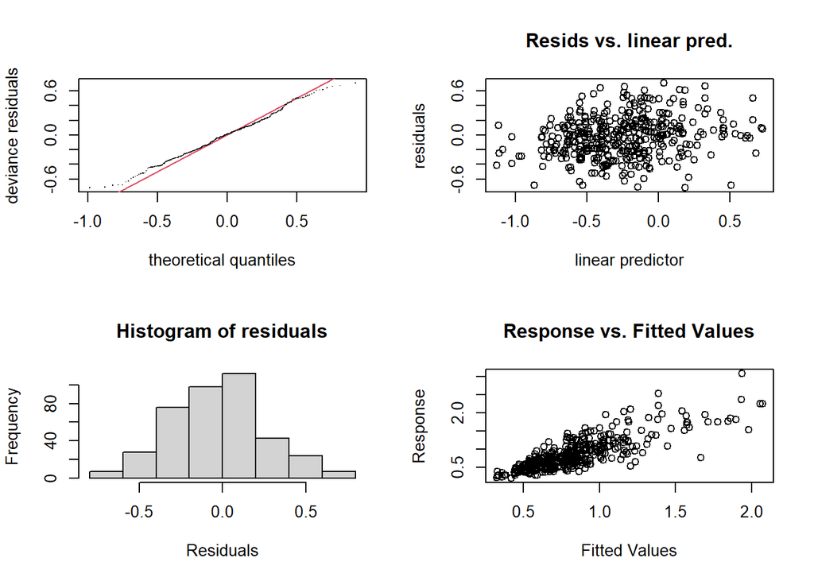

[output not shown]

[output cut: 9 more lines]

```
##
## Basis dimension (k) checking results. Low p-value (k-index<1) may
## indicate that k is too low, especially if edf is close to k'.
##
##                             k'   edf k-index p-value
## s(temp_var)                9.0   1.0     0.9   0.020 *
## s(temp_var):segOK          9.0   1.0     0.9   0.045 *
## s(temp_var):segOT          9.0   1.0     0.9   0.035 *
## s(temp_var):typicalP_O1    9.0   1.0     0.9   0.060 .
## s(temp_var):typicalTK_O1   9.0   1.0     0.9   0.045 *
## s(temp_var,subj)         168.0  25.1     0.9   0.035 *
## s(temp_var,subj):segOK   168.0  29.6     0.9   0.035 *
## s(temp_var,subj):segOT   168.0  26.4     0.9   0.030 *
## ---
## Signif. codes:  0 '***' 0.001 '**' 0.01 '*' 0.05 '.' 0.1 ' ' 1
```

```r
gam.check(mFinalExploratorydf2)
```

Looks allright.

## 7.2 Final Plots

### 7.2.1 Plots with both the constant and non-linear pattern

```r
df2$SegGroup <- interaction(df2$seg, df2$group)

summary(mFinalExploratorydf2inter <- bam(spat_var_bivariate ~ s(temp_var, by = SegGroup) +s(temp_var, subj, by = seg, bs = "fs", m=1), data = df2, family =Gamma(link=log), discrete = T, nthreads = 10))
```

```
##
## Family: Gamma
## Link function: log
##
## Formula:
## spat_var_bivariate ~ s(temp_var, by = SegGroup) + s(temp_var,
##     subj, by = seg, bs = "fs", m = 1)
##
## Parametric coefficients:
##             Estimate Std. Error t value Pr(>|t|)
## (Intercept) -0.28281    0.03456  -8.184    1e-14 ***
## ---
## Signif. codes:  0 '***' 0.001 '**' 0.01 '*' 0.05 '.' 0.1 ' ' 1
##
## Approximate significance of smooth terms:
##                                  edf  Ref.df      F  p-value
## s(temp_var):SegGroupP.PD       1.000   1.000 18.253 2.72e-05 ***
## s(temp_var):SegGroupK.PD       1.189   1.273  0.689 0.356946
## s(temp_var):SegGroupT.PD       1.000   1.000  0.028 0.866603
## s(temp_var):SegGroupP.typical  1.000   1.000  1.827 0.177537
## s(temp_var):SegGroupK.typical  6.139   6.667  4.062 0.000447 ***
## s(temp_var):SegGroupT.typical  1.000   1.000  5.755 0.017097 *
## s(temp_var,subj):segP         25.577 136.000  0.562  < 2e-16 ***
## s(temp_var,subj):segK         40.070 120.000  1.118  < 2e-16 ***
## s(temp_var,subj):segT         39.600 128.000  1.410  < 2e-16 ***
## ---
## Signif. codes:  0 '***' 0.001 '**' 0.01 '*' 0.05 '.' 0.1 ' ' 1
##
## R-sq.(adj) =  0.577   Deviance explained = 71.9%
## fREML = 212.42  Scale est. = 0.094323  n = 395
```

```
## Summary:
##  * temp_var : numeric predictor; with 30 values ranging from 0.000000 to 35.000000.
##  * SegGroup : factor; set to the value(s): P.PD.
##  * subj : factor; set to the value(s): CTRL01. (Might be canceled as random effect, check below.)
##  * seg : factor; set to the value(s): P.
##  * NOTE : The following random effects columns are canceled: s(temp_var,subj):segP,s(temp_var,subj):segK,s(temp_var,subj):segT
##
```

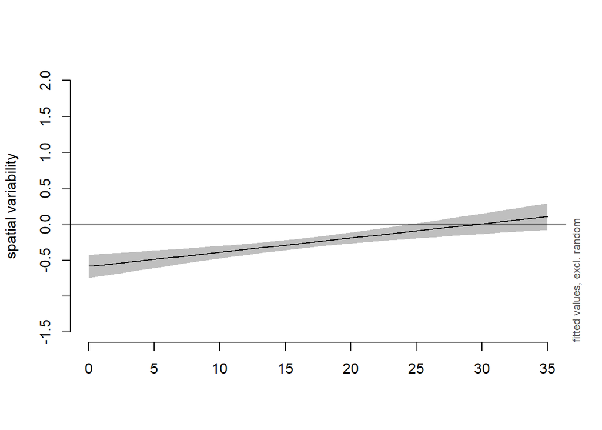

```r
plot_smooth(mFinalExploratorydf2inter, view = "temp_var", cond=list(SegGroup="P.PD"), xlab = "", ylab = "spatial variability", xlim=c(0,35), ylim=c(-1.5,2), rug=FALSE)
```

```
## Summary:
##  * temp_var : numeric predictor; with 30 values ranging from 0.000000 to 35.000000.
##  * SegGroup : factor; set to the value(s): T.PD.
##  * subj : factor; set to the value(s): CTRL01. (Might be canceled as random effect, check below.)
##  * seg : factor; set to the value(s): P.
##  * NOTE : The following random effects columns are canceled: s(temp_var,subj):segP,s(temp_var,subj):segK,s(temp_var,subj):segT
##
```

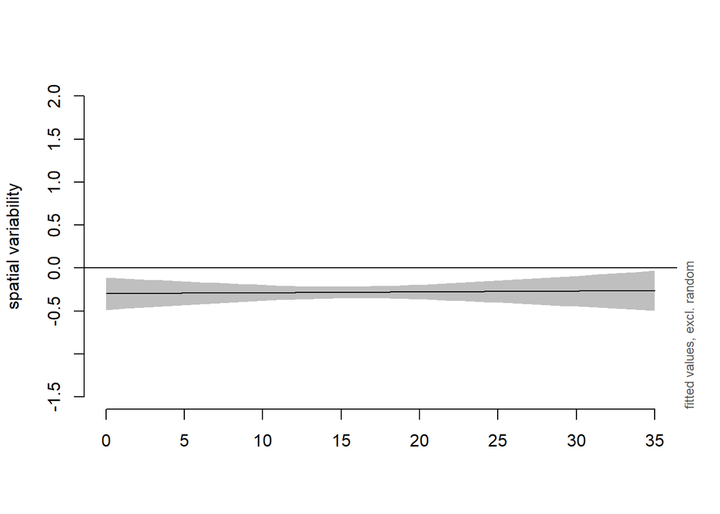

```r
plot_smooth(mFinalExploratorydf2inter, view = "temp_var", cond=list(SegGroup="T.PD"), xlab = "", ylab = "spatial variability", xlim=c(0,35), ylim=c(-1.5,2), rug=FALSE)
```

```
## Summary:
##  * temp_var : numeric predictor; with 30 values ranging from 0.000000 to 35.000000.
##  * SegGroup : factor; set to the value(s): K.PD.
##  * subj : factor; set to the value(s): CTRL01. (Might be canceled as random effect, check below.)
##  * seg : factor; set to the value(s): P.
##  * NOTE : The following random effects columns are canceled: s(temp_var,subj):segP,s(temp_var,subj):segK,s(temp_var,subj):segT
##
```

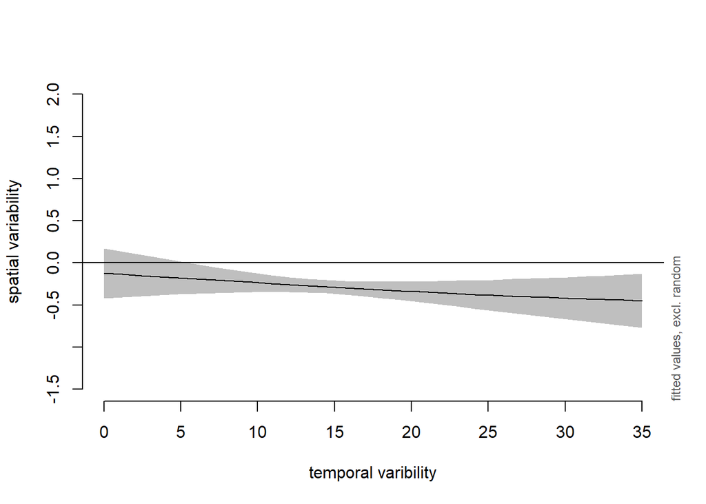

```r
plot_smooth(mFinalExploratorydf2inter, view = "temp_var", cond=list(SegGroup="K.PD"), xlab = "temporal varibility", ylab = "spatial variability", xlim=c(0,35), ylim=c(-1.5,2), rug=FALSE)
```

```
## Summary:
##  * temp_var : numeric predictor; with 30 values ranging from 0.000000 to 35.000000.
##  * SegGroup : factor; set to the value(s): P.typical.
##  * subj : factor; set to the value(s): CTRL01. (Might be canceled as random effect, check below.)
##  * seg : factor; set to the value(s): P.
##  * NOTE : The following random effects columns are canceled: s(temp_var,subj):segP,s(temp_var,subj):segK,s(temp_var,subj):segT
##
```

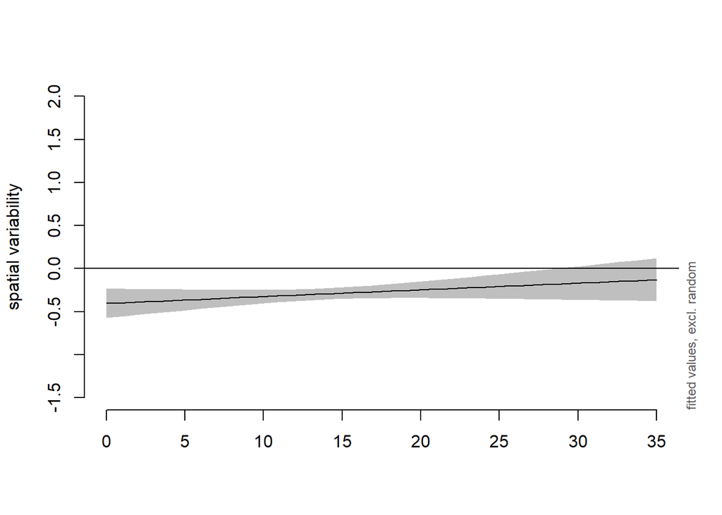

```r
plot_smooth(mFinalExploratorydf2inter, view = "temp_var", cond=list(SegGroup="P.typical"), xlab = "", ylab = "spatial variability", xlim=c(0,35), ylim=c(-1.5,2), rug=FALSE)
```

```
## Summary:
##  * temp_var : numeric predictor; with 30 values ranging from 0.000000 to 35.000000.
##  * SegGroup : factor; set to the value(s): T.typical.
##  * subj : factor; set to the value(s): CTRL01. (Might be canceled as random effect, check below.)
##  * seg : factor; set to the value(s): P.
##  * NOTE : The following random effects columns are canceled: s(temp_var,subj):segP,s(temp_var,subj):segK,s(temp_var,subj):segT
##
```

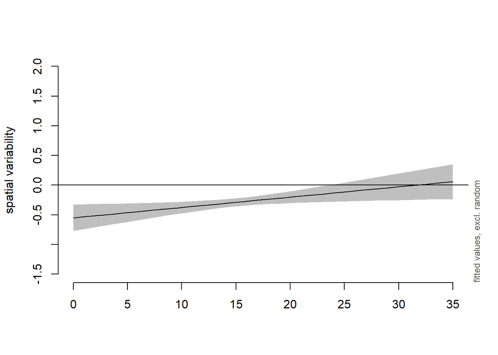

```r
plot_smooth(mFinalExploratorydf2inter, view = "temp_var", cond=list(SegGroup="T.typical"), xlab = "", ylab = "spatial variability", xlim=c(0,35), ylim=c(-1.5,2), rug=FALSE)
```

```
## Summary:
##  * segO : factor; set to the value(s): K.
##  * typicalP_O : factor; set to the value(s): 0.
##  * typicalTK_O : factor; set to the value(s): 1.
##  * temp_var : numeric predictor; with 30 values ranging from 0.000000 to 35.000000.
##  * subj : factor; set to the value(s): CTRL01. (Might be canceled as random effect, check below.)
##  * NOTE : The following random effects columns are canceled: s(temp_var,subj),s(temp_var,subj):segOK,s(temp_var,subj):segOT
##
```

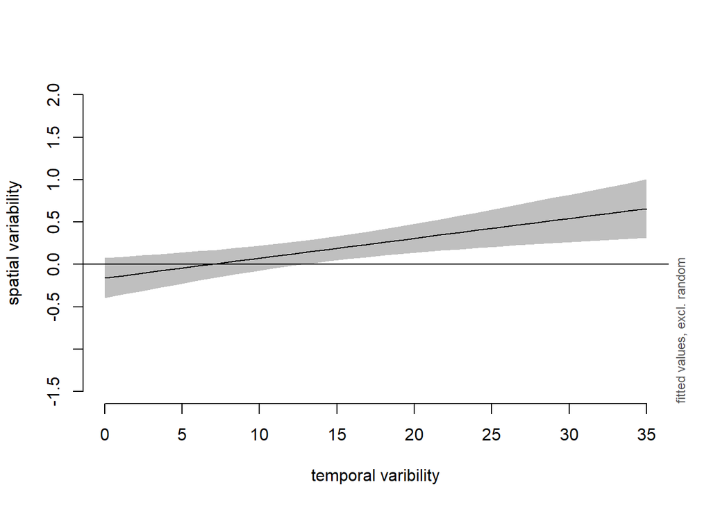

```r
plot_smooth(mFinalExploratorydf2,view='temp_var',cond=list(segO='K',typicalP_O='0',typicalTK_O='1'), xlab = "temporal varibility", ylab = "spatial variability", rm.ranef=T, xlim=c(0,35), ylim=c(-1.5,2), rug=FALSE)
```

### 7.2.2 Plots with only the non-linear pattern

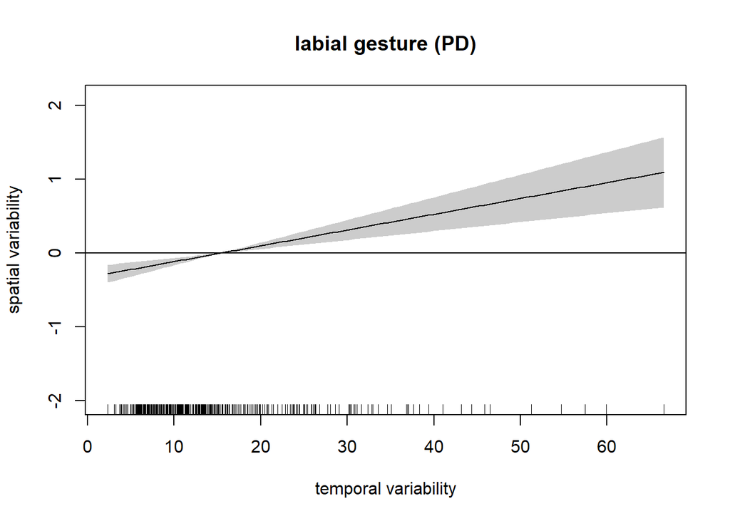

```r
plot(mFinalExploratorydf2, select = 1, main = "labial gesture (PD)", ylab = "spatial variability", shade = T, xlab = "temporal variability")
abline(h=0)
```

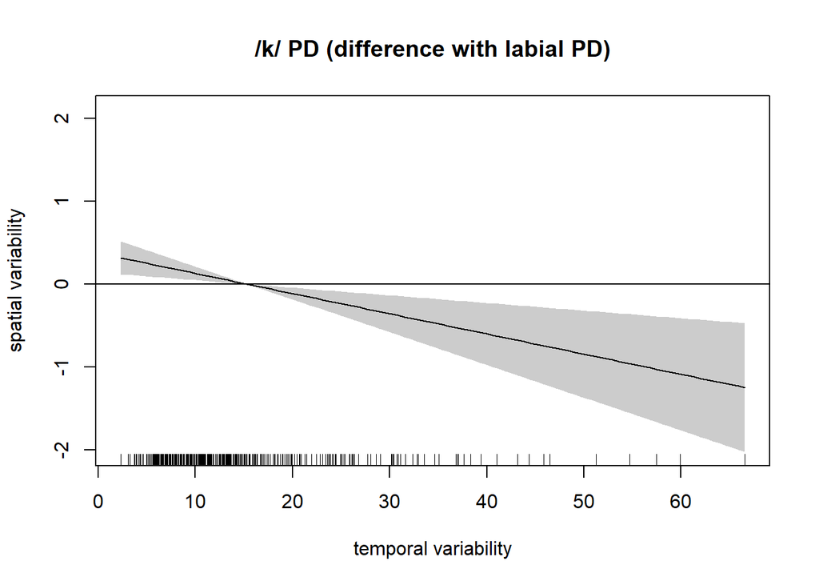

```r
plot(mFinalExploratorydf2, select = 2, main = "/k/ PD (difference with labial PD)", ylab = "spatial variability", shade = T, xlab = "temporal variability")
abline(h=0)
```

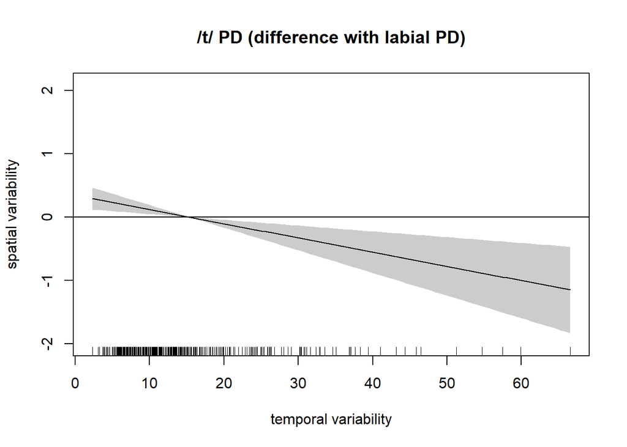

```r
plot(mFinalExploratorydf2, select = 3, main = "/t/ PD (difference with labial PD)", ylab = "spatial variability", shade = T, xlab = "temporal variability")
abline(h=0)
```

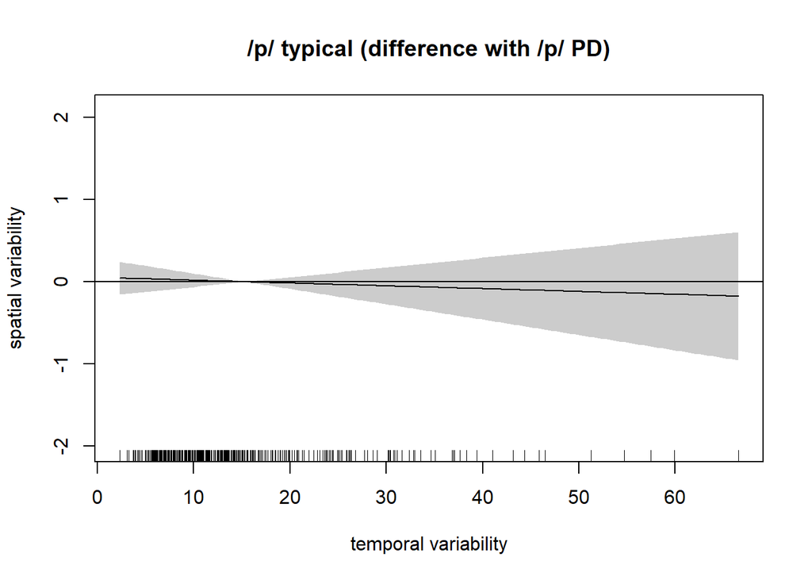

```r
plot(mFinalExploratorydf2, select = 4, main = "/p/ typical (difference with /p/ PD)", ylab = "spatial variability", shade = T, xlab = "temporal variability")
abline(h=0)
```

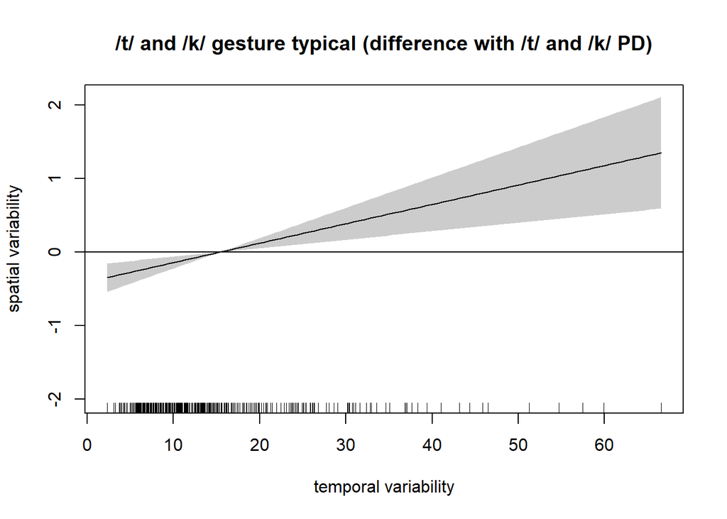

```r
plot(mFinalExploratorydf2, select = 5, main = "/t/ and /k/ gesture typical (difference with /t/ and /k/ PD)", ylab = "spatial variability", shade = T, xlab = "temporal variability")
abline(h=0)
```

Latex table function:

```r
gamtabs2 <- function (model, caption = " ", label = "tab.gam",
    pnames = NA, snames = NA, ptab = NA, stab = NA, ...)
{
    if (!requireNamespace("xtable", quietly = TRUE)) {
        stop("Package 'xtable' needed for this function to work. Please install it.",
            call. = FALSE)
    }
    sum.gam <- model
    if (!inherits(model, "summary.gam")) {
        sum.gam <- summary(model)
    }
    if (is.na(ptab[1])) {
        ptab = as.data.frame(sum.gam$p.table, stringsAsFactors = FALSE)
    }
    if (is.na(stab[1])) {
        stab = as.data.frame(sum.gam$s.table, stringsAsFactors = FALSE)
    }
    if (!is.na(pnames[1])) {
        rownames(ptab) = pnames
    }
    if (!is.na(snames[1])) {
        rownames(stab) = snames
    }
    colnames(ptab)[4] = "p-value"
    colnames(ptab)[3] = "t-value"
    ptab.cnames = colnames(ptab)
    stab.cnames = colnames(stab)
    stab.cnames[3] = "F-value"
    colnames(ptab) = c("A", "B", "C", "D")
    if (ncol(stab) != 0) {
        colnames(stab) = colnames(ptab)
    }
    tab = rbind(ptab, stab)
    colnames(tab) = ptab.cnames
    tab = round(tab, 4)
    m = data.frame(matrix(0, nrow(tab), ncol(tab)), stringsAsFactors = FALSE)
    for (i in 1:nrow(tab)) {
        for (j in 1:4) {
            if ((j == 4) & (tab[i, j] < 1e-03)) {
                m[i, j] = "< 0.001"
            }
            else {
                m[i, j] = sprintf("%3.3f", tab[i, j])
            }
        }
    }
    colnames(m) = colnames(tab)
    rownames(m) = rownames(tab)
    tab = m
    tab2 = rbind(c(ptab.cnames), tab[1:nrow(ptab), ])
    if (nrow(stab) > 0) {
        tab2 = rbind(tab2, c(stab.cnames), tab[(nrow(ptab) +
            1):nrow(tab), ])
    }
    if (nrow(stab)) {
        rownames(tab2)[(nrow(ptab) + 2)] = "B. smooth terms"
    }
    rownames(tab2)[1] = "A. parametric coefficients"
    for (i in 1:nrow(tab2)) {
        if (tab2[i, 4] == "0")
            tab2[i, 4] = "< 0.0001"
        if (length(grep("\\.", tab2[i, 2])) == 0)
            tab2[i, 2] = paste(tab2[i, 2], ".0000", sep = "")
    }
    print(xtable::xtable(tab2, caption = caption, label = label,
        align = "lrrrr"), include.colnames = FALSE, hline.after = c(0,
        (nrow(ptab) + 1), nrow(tab2)), ...)
}
```

Latex table:

```r
options(xtable.comment = FALSE)
gamtabs2(mFinalExploratorydf2)
```

```
## \begin{table}[ht]
## \centering
## \begin{tabular}{lrrrr}
##    \hline
## A. parametric coefficients & Estimate & Std. Error & t-value & p-value \\
##   (Intercept) & -0.450 & 0.052 & -8.582 & $<$ 0.001 \\
##   segOK & 0.161 & 0.080 & 2.027 & 0.043 \\
##   segOT & -0.180 & 0.078 & -2.309 & 0.022 \\
##   typicalP\_O1 & 0.362 & 0.076 & 4.769 & $<$ 0.001 \\
##   typicalTK\_O1 & 0.488 & 0.087 & 5.621 & $<$ 0.001 \\
##    \hline
## B. smooth terms & edf & Ref.df & F-value & p-value \\
##   s(temp\_var) & 1.000 & 1.000 & 21.355 & $<$ 0.001 \\
##   s(temp\_var):segOK & 1.000 & 1.000 & 10.323 & 0.002 \\
##   s(temp\_var):segOT & 1.000 & 1.000 & 11.366 & $<$ 0.001 \\
##   s(temp\_var):typicalP\_O1 & 1.000 & 1.000 & 0.201 & 0.654 \\
##   s(temp\_var):typicalTK\_O1 & 1.000 & 1.000 & 12.710 & $<$ 0.001 \\
##   s(temp\_var,subj) & 25.084 & 159.000 & 0.287 & $<$ 0.001 \\
##   s(temp\_var,subj):segOK & 29.627 & 119.000 & 0.606 & $<$ 0.001 \\
##   s(temp\_var,subj):segOT & 26.424 & 127.000 & 0.471 & $<$ 0.001 \\
##    \hline
## \end{tabular}
## \caption{ }
## \label{tab.gam}
## \end{table}
```

# 8 PD severity

Add years since diagnosis?

```r
summary(mPD1 <- bam(spat_var_bivariate ~ s(diagnosis) + segO + s(temp_var) + s(temp_var, by = segO) + typicalP_O + typicalTK_O + s(temp_var, by = typicalP_O) + s(temp_var, by = typicalTK_O) + s(temp_var, subj, bs = "fs", m=1, k = 4) + s(temp_var, subj, by = segO, bs = "fs", m=1, k = 4), data = df, family =Gamma(link=log), discrete = T, nthreads = 10))
```

```
##
## Family: Gamma
## Link function: log
##
## Formula:
## spat_var_bivariate ~ s(diagnosis) + segO + s(temp_var) + s(temp_var,
##     by = segO) + typicalP_O + typicalTK_O + s(temp_var, by = typicalP_O) +
##     s(temp_var, by = typicalTK_O) + s(temp_var, subj, bs = "fs",
##     m = 1, k = 4) + s(temp_var, subj, by = segO, bs = "fs", m = 1,
##     k = 4)
##
## Parametric coefficients:
##              Estimate Std. Error t value Pr(>|t|)
## (Intercept)  -0.45215    0.05512  -8.203 6.28e-15 ***
## segOK         0.17714    0.08022   2.208 0.027957 *
## segOT        -0.14373    0.08247  -1.743 0.082337 .
## typicalP_O1   0.32646    0.10306   3.168 0.001689 **
## typicalTK_O1  0.42483    0.11140   3.813 0.000165 ***
## ---
## Signif. codes:  0 '***' 0.001 '**' 0.01 '*' 0.05 '.' 0.1 ' ' 1
##
## Approximate significance of smooth terms:
##                            edf Ref.df      F  p-value
## s(diagnosis)              1.00      1  0.230  0.63218
## s(temp_var)               1.00      1 21.926 4.39e-06 ***
## s(temp_var):segOK         1.00      1 10.571  0.00127 **
## s(temp_var):segOT         1.00      1 11.114  0.00096 ***
## s(temp_var):typicalP_O1   1.00      1  0.205  0.65144
## s(temp_var):typicalTK_O1  1.00      1 13.018  0.00036 ***
## s(temp_var,subj)         20.54    158  0.230 1.10e-05 ***
## s(temp_var,subj):segOK   27.18    119  0.498  < 2e-16 ***
## s(temp_var,subj):segOT   27.59    129  0.544  < 2e-16 ***
## ---
## Signif. codes:  0 '***' 0.001 '**' 0.01 '*' 0.05 '.' 0.1 ' ' 1
##
## R-sq.(adj) =  0.529   Deviance explained = 65.1%
## fREML = 203.83  Scale est. = 0.11043   n = 397
```

No.

UPDRS total score?

```r
summary(mPD2 <- bam(spat_var_bivariate ~ s(total_UPDRS) +  segO + s(temp_var) + s(temp_var, by = segO) + typicalP_O + typicalTK_O + s(temp_var, by = typicalP_O) + s(temp_var, by = typicalTK_O) + s(temp_var, subj, bs = "fs", m=1, k = 4) + s(temp_var, subj, by = segO, bs = "fs", m=1, k = 4), data = df, family =Gamma(link=log), discrete = T, nthreads = 10))
```

```
##
## Family: Gamma
## Link function: log
##
## Formula:
## spat_var_bivariate ~ s(total_UPDRS) + segO + s(temp_var) + s(temp_var,
##     by = segO) + typicalP_O + typicalTK_O + s(temp_var, by = typicalP_O) +
##     s(temp_var, by = typicalTK_O) + s(temp_var, subj, bs = "fs",
##     m = 1, k = 4) + s(temp_var, subj, by = segO, bs = "fs", m = 1,
##     k = 4)
##
## Parametric coefficients:
##              Estimate Std. Error t value Pr(>|t|)
## (Intercept)  -0.44607    0.05388  -8.279 3.76e-15 ***
## segOK         0.17628    0.08018   2.199  0.02865 *
## segOT        -0.14491    0.08239  -1.759  0.07959 .
## typicalP_O1   0.32669    0.12118   2.696  0.00740 **
## typicalTK_O1  0.42691    0.12951   3.296  0.00109 **
## ---
## Signif. codes:  0 '***' 0.001 '**' 0.01 '*' 0.05 '.' 0.1 ' ' 1
##
## Approximate significance of smooth terms:
##                            edf Ref.df      F  p-value
## s(total_UPDRS)            1.00      1  0.119 0.730616
## s(temp_var)               1.00      1 21.885 4.48e-06 ***
## s(temp_var):segOK         1.00      1 10.672 0.001210 **
## s(temp_var):segOT         1.00      1 11.309 0.000868 ***
## s(temp_var):typicalP_O1   1.00      1  0.253 0.615636
## s(temp_var):typicalTK_O1  1.00      1 12.951 0.000373 ***
## s(temp_var,subj)         20.64    158  0.232 9.98e-06 ***
## s(temp_var,subj):segOK   27.36    119  0.506  < 2e-16 ***
## s(temp_var,subj):segOT   27.83    129  0.544  < 2e-16 ***
## ---
## Signif. codes:  0 '***' 0.001 '**' 0.01 '*' 0.05 '.' 0.1 ' ' 1
##
## R-sq.(adj) =   0.53   Deviance explained = 65.2%
## fREML = 204.01  Scale est. = 0.11007   n = 397
```

No.

UPDRS motor score?

```r
summary(mPD3 <- bam(spat_var_bivariate ~ s(motor_UPDRS) + segO + s(temp_var) + s(temp_var, by = segO) + typicalP_O + typicalTK_O + s(temp_var, by = typicalP_O) + s(temp_var, by = typicalTK_O) + s(temp_var, subj, bs = "fs", m=1, k = 4) + s(temp_var, subj, by = segO, bs = "fs", m=1, k = 4), data = df, family =Gamma(link=log), discrete = T, nthreads = 10))
```

```
##
## Family: Gamma
## Link function: log
##
## Formula:
## spat_var_bivariate ~ s(motor_UPDRS) + segO + s(temp_var) + s(temp_var,
##     by = segO) + typicalP_O + typicalTK_O + s(temp_var, by = typicalP_O) +
##     s(temp_var, by = typicalTK_O) + s(temp_var, subj, bs = "fs",
##     m = 1, k = 4) + s(temp_var, subj, by = segO, bs = "fs", m = 1,
##     k = 4)
##
## Parametric coefficients:
##              Estimate Std. Error t value Pr(>|t|)
## (Intercept)  -0.44579    0.05380  -8.286 3.53e-15 ***
## segOK         0.17791    0.07991   2.226  0.02670 *
## segOT        -0.14389    0.08221  -1.750  0.08104 .
## typicalP_O1   0.30779    0.11245   2.737  0.00656 **
## typicalTK_O1  0.40530    0.11969   3.386  0.00080 ***
## ---
## Signif. codes:  0 '***' 0.001 '**' 0.01 '*' 0.05 '.' 0.1 ' ' 1
##
## Approximate significance of smooth terms:
##                            edf Ref.df      F  p-value
## s(motor_UPDRS)            1.00      1  0.398 0.528665
## s(temp_var)               1.00      1 21.983 4.27e-06 ***
## s(temp_var):segOK         1.00      1 10.867 0.001092 **
## s(temp_var):segOT         1.00      1 11.545 0.000768 ***
## s(temp_var):typicalP_O1   1.00      1  0.291 0.589826
## s(temp_var):typicalTK_O1  1.00      1 12.876 0.000387 ***
## s(temp_var,subj)         20.74    158  0.230 1.24e-05 ***
## s(temp_var,subj):segOK   26.87    119  0.486 8.77e-07 ***
## s(temp_var,subj):segOT   27.17    129  0.530  < 2e-16 ***
## ---
## Signif. codes:  0 '***' 0.001 '**' 0.01 '*' 0.05 '.' 0.1 ' ' 1
##
## R-sq.(adj) =  0.528   Deviance explained = 64.9%
## fREML = 203.78  Scale est. = 0.11093   n = 397
```

No.

Tremor score?

```r
summary(mPD4 <- bam(spat_var_bivariate ~ s(tremor, k= 6) +  segO + s(temp_var) + s(temp_var, by = segO) + typicalP_O + typicalTK_O + s(temp_var, by = typicalP_O) + s(temp_var, by = typicalTK_O) + s(temp_var, subj, bs = "fs", m=1, k = 4) + s(temp_var, subj, by = segO, bs = "fs", m=1, k = 4), data = df, family =Gamma(link=log), discrete = T, nthreads = 10))
```

```
##
## Family: Gamma
## Link function: log
##
## Formula:
## spat_var_bivariate ~ s(tremor, k = 6) + segO + s(temp_var) +
##     s(temp_var, by = segO) + typicalP_O + typicalTK_O + s(temp_var,
##     by = typicalP_O) + s(temp_var, by = typicalTK_O) + s(temp_var,
##     subj, bs = "fs", m = 1, k = 4) + s(temp_var, subj, by = segO,
##     bs = "fs", m = 1, k = 4)
##
## Parametric coefficients:
##              Estimate Std. Error t value Pr(>|t|)
## (Intercept)  -0.48021    0.06646  -7.225 3.90e-12 ***
## segOK         0.18361    0.08023   2.289   0.0228 *
## segOT        -0.13832    0.08337  -1.659   0.0981 .
## typicalP_O1   0.33940    0.08533   3.978 8.67e-05 ***
## typicalTK_O1  0.43050    0.09642   4.465 1.12e-05 ***
## ---
## Signif. codes:  0 '***' 0.001 '**' 0.01 '*' 0.05 '.' 0.1 ' ' 1
##
## Approximate significance of smooth terms:
##                             edf  Ref.df      F  p-value
## s(tremor)                 1.128   1.174  0.284 0.563226
## s(temp_var)               1.000   1.000 22.637 3.69e-06 ***
## s(temp_var):segOK         1.000   1.000 10.772 0.001148 **
## s(temp_var):segOT         1.000   1.000 11.247 0.000896 ***
## s(temp_var):typicalP_O1   1.000   1.000  0.214 0.644011
## s(temp_var):typicalTK_O1  1.000   1.000 13.221 0.000324 ***
## s(temp_var,subj)         19.430 158.000  0.218 1.40e-05 ***
## s(temp_var,subj):segOK   27.475 119.000  0.509  < 2e-16 ***
## s(temp_var,subj):segOT   28.567 129.000  0.572  < 2e-16 ***
## ---
## Signif. codes:  0 '***' 0.001 '**' 0.01 '*' 0.05 '.' 0.1 ' ' 1
##
## R-sq.(adj) =   0.53   Deviance explained = 65.2%
## fREML = 203.55  Scale est. = 0.10975   n = 397
```

No.

## 8.1 Without typicals:

Subset data to contain only PD:

```r
dfPD <- subset(df, group == "PD")
```

Add years since diagnosis?

```r
summary(mPD1 <- bam(spat_var_bivariate ~ s(diagnosis) + segO + s(temp_var) + s(temp_var, by = segO) + s(temp_var, subj, bs = "fs", m=1, k = 4) + s(temp_var, subj, by = segO, bs = "fs", m=1, k = 4), data = dfPD, family =Gamma(link=log), discrete = T, nthreads = 10))
```

```
##
## Family: Gamma
## Link function: log
##
## Formula:
## spat_var_bivariate ~ s(diagnosis) + segO + s(temp_var) + s(temp_var,
##     by = segO) + s(temp_var, subj, bs = "fs", m = 1, k = 4) +
##     s(temp_var, subj, by = segO, bs = "fs", m = 1, k = 4)
##
## Parametric coefficients:
##             Estimate Std. Error t value Pr(>|t|)
## (Intercept) -0.38652    0.05326  -7.258 2.78e-11 ***
## segOK        0.08562    0.09855   0.869   0.3865
## segOT       -0.20353    0.10768  -1.890   0.0609 .
## ---
## Signif. codes:  0 '***' 0.001 '**' 0.01 '*' 0.05 '.' 0.1 ' ' 1
##
## Approximate significance of smooth terms:
##                           edf Ref.df      F  p-value
## s(diagnosis)            1.000  1.000  0.130  0.71930
## s(temp_var)             1.000  1.000 24.339 2.49e-06 ***
## s(temp_var):segOK       1.071  1.112  9.460  0.00166 **
## s(temp_var):segOT       1.000  1.000  7.419  0.00731 **
## s(temp_var,subj)        6.537 71.000  0.158  0.00641 **
## s(temp_var,subj):segOK 15.773 54.000  0.738 3.52e-05 ***
## s(temp_var,subj):segOT 13.328 57.000  0.828  < 2e-16 ***
## ---
## Signif. codes:  0 '***' 0.001 '**' 0.01 '*' 0.05 '.' 0.1 ' ' 1
##
## R-sq.(adj) =  0.417   Deviance explained = 63.7%
## fREML =  101.2  Scale est. = 0.11616   n = 178
```

No.

UPDRS total score?

```r
summary(mPD2 <- bam(spat_var_bivariate ~ s(total_UPDRS) +  segO + s(temp_var) + s(temp_var, by = segO) + s(temp_var, subj, bs = "fs", m=1, k = 4) + s(temp_var, subj, by = segO, bs = "fs", m=1, k = 4), data = dfPD, family =Gamma(link=log), discrete = T, nthreads = 10))
```

```
##
## Family: Gamma
## Link function: log
##
## Formula:
## spat_var_bivariate ~ s(total_UPDRS) + segO + s(temp_var) + s(temp_var,
##     by = segO) + s(temp_var, subj, bs = "fs", m = 1, k = 4) +
##     s(temp_var, subj, by = segO, bs = "fs", m = 1, k = 4)
##
## Parametric coefficients:
##             Estimate Std. Error t value Pr(>|t|)
## (Intercept) -0.38559    0.05281  -7.302 2.21e-11 ***
## segOK        0.08699    0.09924   0.877   0.3823
## segOT       -0.20282    0.10789  -1.880   0.0623 .
## ---
## Signif. codes:  0 '***' 0.001 '**' 0.01 '*' 0.05 '.' 0.1 ' ' 1
##
## Approximate significance of smooth terms:
##                          edf Ref.df      F  p-value
## s(total_UPDRS)          1.00  1.000  0.016  0.89842
## s(temp_var)             1.00  1.000 23.395 3.73e-06 ***
## s(temp_var):segOK       1.05  1.079  9.755  0.00159 **
## s(temp_var):segOT       1.00  1.000  7.416  0.00732 **
## s(temp_var,subj)        6.59 71.000  0.160  0.00630 **
## s(temp_var,subj):segOK 15.92 54.000  0.766 2.22e-05 ***
## s(temp_var,subj):segOT 13.40 57.000  0.828 7.14e-07 ***
## ---
## Signif. codes:  0 '***' 0.001 '**' 0.01 '*' 0.05 '.' 0.1 ' ' 1
##
## R-sq.(adj) =  0.418   Deviance explained = 63.8%
## fREML = 101.17  Scale est. = 0.11554   n = 178
```

No.

UPDRS motor score?

```r
summary(mPD3 <- bam(spat_var_bivariate ~ s(motor_UPDRS) + segO + s(temp_var) + s(temp_var, by = segO) + s(temp_var, subj, bs = "fs", m=1, k = 4) + s(temp_var, subj, by = segO, bs = "fs", m=1, k = 4), data = dfPD, family =Gamma(link=log), discrete = T, nthreads = 10))
```

```
##
## Family: Gamma
## Link function: log
##
## Formula:
## spat_var_bivariate ~ s(motor_UPDRS) + segO + s(temp_var) + s(temp_var,
##     by = segO) + s(temp_var, subj, bs = "fs", m = 1, k = 4) +
##     s(temp_var, subj, by = segO, bs = "fs", m = 1, k = 4)
##
## Parametric coefficients:
##             Estimate Std. Error t value Pr(>|t|)
## (Intercept) -0.38580    0.05264  -7.330 1.88e-11 ***
## segOK        0.08931    0.09837   0.908   0.3656
## segOT       -0.20236    0.10742  -1.884   0.0617 .
## ---
## Signif. codes:  0 '***' 0.001 '**' 0.01 '*' 0.05 '.' 0.1 ' ' 1
##
## Approximate significance of smooth terms:
##                           edf Ref.df      F  p-value
## s(motor_UPDRS)          1.000  1.000  0.112  0.73836
## s(temp_var)             1.000  1.000 23.467 3.59e-06 ***
## s(temp_var):segOK       1.060  1.095  9.740  0.00152 **
## s(temp_var):segOT       1.000  1.000  7.582  0.00670 **
## s(temp_var,subj)        6.504 71.000  0.156  0.00670 **
## s(temp_var,subj):segOK 15.713 54.000  0.731 3.94e-05 ***
## s(temp_var,subj):segOT 13.195 57.000  0.806 9.12e-07 ***
## ---
## Signif. codes:  0 '***' 0.001 '**' 0.01 '*' 0.05 '.' 0.1 ' ' 1
##
## R-sq.(adj) =  0.415   Deviance explained = 63.5%
## fREML = 101.04  Scale est. = 0.11668   n = 178
```

No.

Tremor score?

```r
summary(mPD4 <- bam(spat_var_bivariate ~ s(tremor, k= 6) +  segO + s(temp_var) + s(temp_var, by = segO) + s(temp_var, subj, bs = "fs", m=1, k = 4) + s(temp_var, subj, by = segO, bs = "fs", m=1, k = 4), data = dfPD, family =Gamma(link=log), discrete = T, nthreads = 10))
```

```
##
## Family: Gamma
## Link function: log
##
## Formula:
## spat_var_bivariate ~ s(tremor, k = 6) + segO + s(temp_var) +
##     s(temp_var, by = segO) + s(temp_var, subj, bs = "fs", m = 1,
##     k = 4) + s(temp_var, subj, by = segO, bs = "fs", m = 1, k = 4)
##
## Parametric coefficients:
##             Estimate Std. Error t value Pr(>|t|)
## (Intercept) -0.41536    0.06485  -6.405 2.32e-09 ***
## segOK        0.08161    0.09759   0.836   0.4045
## segOT       -0.20727    0.11073  -1.872   0.0634 .
## ---
## Signif. codes:  0 '***' 0.001 '**' 0.01 '*' 0.05 '.' 0.1 ' ' 1
##
## Approximate significance of smooth terms:
##                           edf Ref.df      F  p-value
## s(tremor)               1.186  1.260  0.464  0.45644
## s(temp_var)             1.000  1.000 24.458 2.37e-06 ***
## s(temp_var):segOK       1.086  1.135  9.355  0.00161 **
## s(temp_var):segOT       1.000  1.000  7.260  0.00795 **
## s(temp_var,subj)        6.122 71.000  0.142  0.00867 **
## s(temp_var,subj):segOK 15.874 54.000  0.761 2.32e-05 ***
## s(temp_var,subj):segOT 13.901 57.000  0.898 3.79e-07 ***
## ---
## Signif. codes:  0 '***' 0.001 '**' 0.01 '*' 0.05 '.' 0.1 ' ' 1
##
## R-sq.(adj) =  0.422   Deviance explained = 64.2%
## fREML =  100.5  Scale est. = 0.11417   n = 178
```

No.